# Relatório da disciplina: Modelos Lineares Generalizados e Aditivos para Dados Ecológicos

Bianca Guerreiro

12-10-2025

# 1 GLM para dados binários

## 1.1 Introdução

Dados binários são caracterizados por variáveis que assumem apenas dois estados possíveis, geralmente representados como 0 e 1, correspondendo a eventos de sucesso/fracasso ou ocorrência/não ocorrência etc. Esse tipo de dado é comum em estudos ecológicos, nos quais frequentemente se deseja modelar a probabilidade de ocorrência de uma espécie em função de características ambientais.

Neste relatório, aplicaremos modelos lineares generalizados (GLMs) com distribuição binomial para analisar a ocorrência do guigó-da-Caatinga (*Callicebus barbarabrownae*), um primata endêmico e ameaçado da Caatinga. Aqui, o objetivo é avaliar como a estrutura do entorno desses fragmentos, representada por atributos da paisagem, influencia a probabilidade de ocorrência de *C. barbarabrownae*.

Para definir as paisagens de presença e ausência da espécie, compilamos registros primários (aqueles feitos pelos próprios autores em campo) da literatura contendo informações de presença e ausência da espécie em diferentes fragmentos florestais.

Vejamos as informações contidas no banco de dados:

```r
dados <- read.csv("binomial/relat_dados_ocorrencia_cap2.csv")
```

```r
str(dados)
```

```
## 'data.frame':    840 obs. of  13 variables:
##  $ ID              : chr  "F01" "F01" "F01" "F01" ...
##  $ buffer          : int  1266 1555 1844 2133 2422 2711 3000 399 688 977 ...
##  $ situacao        : chr  "presenca" "presenca" "presenca" "presenca" ...
##  $ prop_habitat    : num  90.9 87.4 85.7 83.9 84.1 ...
##  $ dens_frags      : num  0.198 0.79 0.468 0.7 0.434 ...
##  $ media_area_frags: num  458 111 183 120 194 ...
##  $ med_dist_eucl   : num  NA 76.3 65.6 85.3 65.3 ...
##  $ pcore           : num  77.2 74.7 73.5 72.4 73.3 ...
##  $ dens_borda      : num  48 47.8 47.9 45.6 44.1 ...
##  $ shape_mn        : num  3.87 1.76 2.05 1.75 2.09 ...
##  $ iagreg          : num  96 95.9 95.9 95.9 96.1 ...
##  $ clumpy          : num  0.72 0.768 0.778 0.802 0.802 ...
##  $ coesao          : num  99.9 99.9 99.9 99.9 99.9 ...
```

`dados$ID` representa a identidade de cada paisagem estudada. Ao todo, o banco de dados tem 84 paisagens distintas.

```r
length(unique(dados$ID))
```

```
## [1] 84
```

A variável `dados$buffer` indica o tamanho (raio) considerado para cada paisagem. Em estudos de ecologia da paisagem, é recomendável que o tamanho da paisagem seja definido a partir de uma análise de escala do efeito, a fim de identificar a escala na qual a variável dependente é melhor explicada pelas variáveis independentes do modelo. No presente conjunto de dados, cada paisagem foi avaliada em 10 tamanhos de buffer diferentes.

```r
table(dados$buffer) #cada buffer é repetido 84 vezes (que é o número total de paisagens)
```

```
##
##  399  688  977 1266 1555 1844 2133 2422 2711 3000
##   84   84   84   84   84   84   84   84   84   84
```

```r
#ou:
table(unique(dados[, c("ID", "buffer")])$ID) #cada paisagem contem 10 tamanhos de buffer
```

```
##
##  F01  F02  F03  F04  F05  F06  F07  F08  F10 F100 F101  F11  F12  F13  F14  F15
##   10   10   10   10   10   10   10   10   10   10   10   10   10   10   10   10
##  F16  F17  F18  F19  F20  F21  F22  F23  F24  F25  F26  F27  F28  F29  F30  F32
##   10   10   10   10   10   10   10   10   10   10   10   10   10   10   10   10
##  F33  F35  F36  F37  F38  F39  F40  F41  F42  F43  F44  F45  F46  F47  F48  F49
##   10   10   10   10   10   10   10   10   10   10   10   10   10   10   10   10
##  F50  F51  F52  F53  F54  F55  F56  F57  F58  F59  F60  F62  F63  F64  F65  F67
##   10   10   10   10   10   10   10   10   10   10   10   10   10   10   10   10
##  F68  F70  F72  F74  F76  F77  F78  F80  F81  F82  F83  F85  F86  F88  F91  F92
##   10   10   10   10   10   10   10   10   10   10   10   10   10   10   10   10
##  F94  F95  F96  F97
##   10   10   10   10
```

A variável `dados$situacao` indica se há presença ou ausência do guigó em cada paisagem. Ao todo, são 38 paisagens de ausência e 46 paisagens de presença.

```r
table(unique(dados[, c("ID", "situacao")])$situacao)
```

```
##
## ausencia presenca
##       38       46
```

`dados[,4:13]` são diferentes métricas da paisagem, calculadas a partir do pacote `landscapemetrics` (Hesselbarth et al., 2019) com base em imagens da Coleção 7 do MapBiomas, referentes ao ano de 2021. Onde:

- `dados$prop_habitat` é a proporção de floresta na paisagem (em %);
- `dados$dens_frags` é a densidade de fragmentos da paisagem (frags/100 ha);
- `dados$media_area_frags` é a média da área de todos os fragmentos da paisagem (ha);
- `dados$med_dist_eucl` é a média da distância euclidiana do vizinho mais próximo (calculada para cada fragmento da paisagem e expressa em metros);
- `dados$pcore` diferente das outras métricas, essa é calculada apenas para o fragmento em que foi registrada a presença ou ausência da espécie (fragmento central da paisagem). Mede a área central do fragmento (em hectares), desconsiderando a borda;
- `dados$dens_borda` é a densidade de borda dos fragmentos da paisagem (m/ha);
- `dados$shape_mn` é um índice que mede o formato médio dos fragmentos da paisagem. Seu valor é sempre maior ou igual a 1; quanto mais próximo de 1, mais próximo de uma forma quadrada é o fragmento, e quanto mais distante de 1, mais complexo é o formato;
- `dados$iagreg` é uma métrica de agregação, que indica o grau de agrupamento entre os fragmentos de floresta, variando de 0% (fragmentos mais isolados) a 100% (fragmentos mais próximos e conectados);
- `dados$clumpy` é o índice de aglomeração, que mede o padrão de distribuição espacial dos fragmentos. Valores próximos de 1 indicam paisagens altamente agregadas, enquanto valores próximos de 0 indicam uma distribuição mais aleatória;
- `dados$coesao` é o índice de coesão, que expressa o grau de conectividade física entre fragmentos de floresta na paisagem (em %). Quanto maior o valor, mais conectada e estruturalmente coesa é a paisagem.

## 1.2 Checando multicolinearidade

Como possuímos várias variáveis independentes, o primeiro passo é selecionar aquelas que não estejam fortemente correlacionadas entre si. Como temos 10 diferentes tamanhos de paisagem, o ideal seria avaliar cuidadosamente as correlações entre as métricas em cada tamanho de buffer.

A seguir, apresentarei *os resultados dos testes de correlação realizados para a maior paisagem (buffer com raio de 3000 m)*.

Para verificar a multicolinearidade entre as métricas de paisagem, calculei as correlações pareadas entre todas as variáveis utilizando o coeficiente de correlação de Pearson, por meio da função `cor()` do R.

```r
b3000 <- subset(dados, buffer== "3000") #selecionando apenas os buffers de raio de 3000m

# Correlation matrix
nrow(b3000) #checando se estão as 84 paisagens
```

```
## [1] 84
```

```r
names(b3000) #checando as colunas que contém minhas variáveis independentes
```

```
##  [1] "ID"               "buffer"           "situacao"         "prop_habitat"
##  [5] "dens_frags"       "media_area_frags" "med_dist_eucl"    "pcore"
##  [9] "dens_borda"       "shape_mn"         "iagreg"           "clumpy"
## [13] "coesao"
```

```r
M <- cor(b3000[4:13], use = "complete.obs")
round(M,2)
```

```
##                  prop_habitat dens_frags media_area_frags med_dist_eucl pcore
## prop_habitat             1.00      -0.81             0.58         -0.66  0.99
## dens_frags              -0.81       1.00            -0.57          0.25 -0.85
## media_area_frags         0.58      -0.57             1.00         -0.15  0.63
## med_dist_eucl           -0.66       0.25            -0.15          1.00 -0.58
## pcore                    0.99      -0.85             0.63         -0.58  1.00
## dens_borda              -0.27       0.56            -0.49         -0.26 -0.43
## shape_mn                 0.23      -0.27             0.71         -0.03  0.23
## iagreg                   0.91      -0.86             0.52         -0.46  0.93
## clumpy                   0.25      -0.45             0.13          0.15  0.34
## coesao                   0.77      -0.59             0.29         -0.60  0.70
##                  dens_borda shape_mn iagreg clumpy coesao
## prop_habitat          -0.27     0.23   0.91   0.25   0.77
## dens_frags             0.56    -0.27  -0.86  -0.45  -0.59
## media_area_frags      -0.49     0.71   0.52   0.13   0.29
## med_dist_eucl         -0.26    -0.03  -0.46   0.15  -0.60
## pcore                 -0.43     0.23   0.93   0.34   0.70
## dens_borda             1.00    -0.07  -0.43  -0.62   0.13
## shape_mn              -0.07     1.00   0.12  -0.21   0.13
## iagreg                -0.43     0.12   1.00   0.57   0.76
## clumpy                -0.62    -0.21   0.57   1.00   0.23
## coesao                 0.13     0.13   0.76   0.23   1.00
```

Aqui, adotei o limiar de |r| > 0.7 para indicar correlação forte. Quando duas métricas apresentaram correlação elevada, e uma delas era `dados$prop_habitat`, essa última foi priorizada para ser mantida, considerando sua importância ecológica para a espécie-alvo.

Dessa forma, pelos valores de correlação de Pearson, as métricas mque não estão correlacionadas com `dados$prop_habitat` são:

- `dados$media_area_frags`;
- `dados$med_dist_eucl`;
- `dados$dens_borda`;
- `dados$shape_mn`;
- `dados$clumpy`;

Mas, dessas, `dados$shape_mn` e `dados$media_area_frags` estão positivamente correlacionadas (r = 0.71).

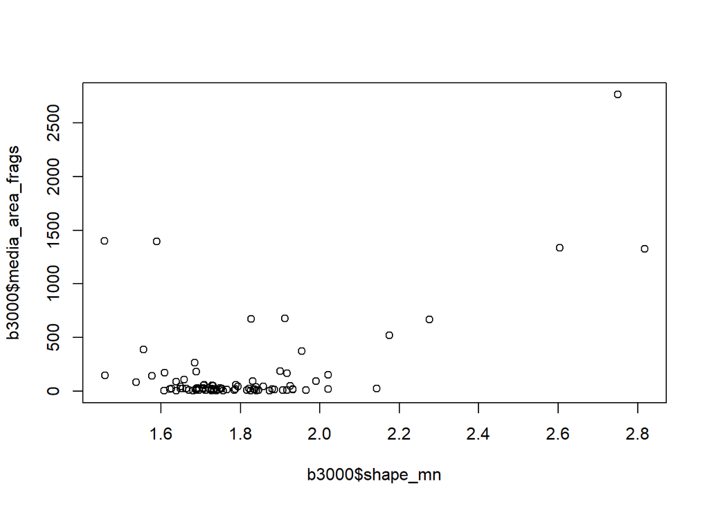

```r
plot(b3000$shape_mn, b3000$media_area_frags)
```

Como o formato médio dos fragmentos (`dados$shape_mn`) é principalmente um proxy da quantidade de borda na paisagem e já possuimos uma métrica para isso (`dados$dens_borda`), manterei `dados$media_area_frags` que dá uma informação da área média dos fragmentos na paisagem.

Assim, as métricas selecionadas para explicar a ocorrência da espécie nas paisagens geradas pelo buffer de 3000m, serão:

- `dados$prop_habitat`;
- `dados$media_area_frags`;
- `dados$med_dist_eucl`;
- `dados$dens_borda`;
- `dados$clumpy`;

O resultado das análises de multicolinearidade para os demais tamanhos de buffer no código a seguir, mas, para não alongar o relatório, deixei o resultado em formato de comentário no própio código.

```r
# Checando as correlações para os outros tamanhos de paisagem

## subsets para os outros tamanhos
b399 <- subset(dados, buffer== "399")
b688 <- subset(dados, buffer== "688")
b977 <- subset(dados, buffer== "977")
b1266 <- subset(dados, buffer== "1266")
b1555 <- subset(dados, buffer== "1555")
b1844 <- subset(dados, buffer== "1844")
b2133 <- subset(dados, buffer== "2133")
b2422 <- subset(dados, buffer== "2422")
b2711 <- subset(dados, buffer== "2711")

# Correlação métricas b399
M <- cor(b399[4:13], use = "complete.obs")
round(M,2)
# Priorizando a prop_habitat, ficam: dens_frags, med_dist_eucl, shape_mn e clumpy

# Correlação métricas b688
M <- cor(b688[4:13], use = "complete.obs")
round(M,2)
# Priorizando a prop_habitat, ficam: dens_frags, med_dist_eucl, shape_mn e clumpy

# Correlação métricas b977
M <- cor(b977[4:13], use = "complete.obs")
round(M,2)
# Priorizando a prop_habitat, ficam: dens_frags, med_dist_eucl, shape_mn e clumpy

# Correlação métricas b1266
M <- cor(b1266[4:13], use = "complete.obs")
round(M,2)
# Priorizando a prop_habitat, ficam: med_dist_eucl, shape_mn e clumpy

# Correlação métricas b1555
M <- cor(b1555[4:13], use = "complete.obs")
round(M,2)
# Priorizando a prop_habitat, ficam: shape_mn e clumpy

# Correlação métricas b1844
M <- cor(b1844[4:13], use = "complete.obs")
round(M,2)
# Priorizando a prop_habitat, ficam: med_area_frags, shape_mn e clumpy

# Correlação métricas b2133
M <- cor(b2133[4:13], use = "complete.obs")
round(M,2)
# Priorizando a prop_habitat, ficam: med_dist_eucl, shape_mn e clumpy

# Correlação métricas b2422
M <- cor(b2422[4:13], use = "complete.obs")
round(M,2)
# Priorizando a prop_habitat, ficam: med_area_frags, med_dist_eucl, shape_mn e clumpy

# Correlação métricas b2711
M <- cor(b2711[4:13], use = "complete.obs")
round(M,2)
# Priorizando a prop_habitat, ficam: med_area_frags, med_dist_eucl, shape_mn e clumpy
```

## 1.3 Análise exploratória

Utilizarei apenas o buffer de 3000m de raio como exemplo para uma breve análise exploratória dos dados.

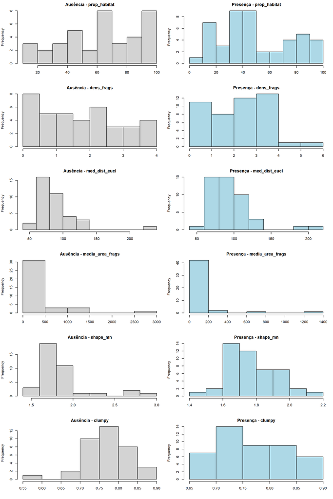

```r
b3000 <- subset(dados, buffer== "3000") #selecionando o buffer de 3000m
b3000_occur <- subset(b3000, situacao== "presenca") #criando subset para ocorrência
b3000_absc <- subset(b3000, situacao== "ausencia") #criando subset para ausência

par(mfrow = c(6, 2))
par(mar = c(4, 4, 2, 1))
#prop_habitat
hist(b3000_absc$prop_habitat, main = "Ausência - prop_habitat", xlab = "", col = "lightgray")
hist(b3000_occur$prop_habitat, main = "Presença - prop_habitat", xlab = "", col = "lightblue")

#dens_frags
hist(b3000_absc$dens_frags, main = "Ausência - dens_frags", xlab = "", col = "lightgray")
hist(b3000_occur$dens_frags, main = "Presença - dens_frags", xlab = "", col = "lightblue")

#med_dist_eucl
hist(b3000_absc$med_dist_eucl, main = "Ausência - med_dist_eucl", xlab = "", col = "lightgray")
hist(b3000_occur$med_dist_eucl, main = "Presença - med_dist_eucl", xlab = "", col = "lightblue")

#media_area_frags
hist(b3000_absc$media_area_frags, main = "Ausência - media_area_frags", xlab = "", col = "lightgray")
hist(b3000_occur$media_area_frags, main = "Presença - media_area_frags", xlab = "", col = "lightblue")

#shape_mn
hist(b3000_absc$shape_mn, main = "Ausência - shape_mn", xlab = "", col = "lightgray")
hist(b3000_occur$shape_mn, main = "Presença - shape_mn", xlab = "", col = "lightblue")

#clumpy
hist(b3000_absc$clumpy, main = "Ausência - clumpy", xlab = "", col = "lightgray")
hist(b3000_occur$clumpy, main = "Presença - clumpy", xlab = "", col = "lightblue")
```

Os painéis à esquerda correspondem às paisagens classificadas como ausência (em cinza), enquanto os painéis à direita representam as paisagens de presença (em azul).

## 1.4 Transformando as variáveis

Essas são as variáveis do conjunto de dados:

```r
str(dados)
```

```
## 'data.frame':    840 obs. of  13 variables:
##  $ ID              : chr  "F01" "F01" "F01" "F01" ...
##  $ buffer          : int  1266 1555 1844 2133 2422 2711 3000 399 688 977 ...
##  $ situacao        : chr  "presenca" "presenca" "presenca" "presenca" ...
##  $ prop_habitat    : num  90.9 87.4 85.7 83.9 84.1 ...
##  $ dens_frags      : num  0.198 0.79 0.468 0.7 0.434 ...
##  $ media_area_frags: num  458 111 183 120 194 ...
##  $ med_dist_eucl   : num  NA 76.3 65.6 85.3 65.3 ...
##  $ pcore           : num  77.2 74.7 73.5 72.4 73.3 ...
##  $ dens_borda      : num  48 47.8 47.9 45.6 44.1 ...
##  $ shape_mn        : num  3.87 1.76 2.05 1.75 2.09 ...
##  $ iagreg          : num  96 95.9 95.9 95.9 96.1 ...
##  $ clumpy          : num  0.72 0.768 0.778 0.802 0.802 ...
##  $ coesao          : num  99.9 99.9 99.9 99.9 99.9 ...
```

Precisamos transformar algumas variáveis:

-`dados$ID` está como *character* e deve ser convertida para *factor*, caso seja incluída posteriormente nos modelos;

-`dados$buffer` está como número inteiro, mas será convertida para *factor*, caso se deseje incluí-la como variável explicativa;

-`dados$situacao` está como *character*, mas corresponde à nossa variável resposta binária. Assim, será transformada em valores 0 e 1, sendo 1 para presença (sucesso de ocorrência do guigó) e 0 para ausência (insucesso de ocorrência).

```r
cols <- c("ID", "buffer") #colunas que quero transformar em factor
dados[, cols] <- lapply(dados[, cols], factor)
dados$situacao <- ifelse(dados$situacao == "presenca", 1, 0) #transformando presença em 1 e ausência em 0
```

## 1.5 Gerando modelos

Como para cada tamanho de buffer foram selecionadas métricas diferentes, irei gerar os modelos para cada um deles. Utilizei GLMs com distribuição binomial e função de ligação logit.

Modelos nulos:

```r
### Nulo ----
b399_null_model <- glm(situacao ~ 1, family = binomial(link = logit), data = b399)
b688_null_model <- glm(situacao ~ 1, family = binomial(link = logit), data = b688)
b977_null_model <- glm(situacao ~ 1, family = binomial(link = logit), data = b977)
b1266_null_model <- glm(situacao ~ 1, family = binomial(link = logit), data = b1266)
b1555_null_model <- glm(situacao ~ 1, family = binomial(link = logit), data = b1555)
b1844_null_model <- glm(situacao ~ 1, family = binomial(link = logit), data = b1844)
b2133_null_model <- glm(situacao ~ 1, family = binomial(link = logit), data = b2133)
b2422_null_model <- glm(situacao ~ 1, family = binomial(link = logit), data = b2422)
b2711_null_model <- glm(situacao ~ 1, family = binomial(link = logit), data = b2711)
b3000_null_model <- glm(situacao ~ 1, family = binomial(link = logit), data = b3000)
```

Como são muitos modelos (e combinações possíveis), uso uma função que gera todas combinações possíveis e salva cada modelo em um objeto:

```r
### Função para criar todos os modelos e gerar objetos separados
create_glm_models_objects <- function(data, vars, prefix){
  model_names <- c()  # vetor para armazenar nomes dos modelos criados

  for(n in 1:length(vars)){
    combos <- combn(vars, n, simplify = FALSE)

    for(i in seq_along(combos)){
        f <- as.formula(paste("situacao ~", paste0("scale(", combos[[i]], ")", collapse = " + ")))
        model_name <- paste0(prefix, "_", paste(combos[[i]], collapse = "_")) # Nome do objeto baseado nas variáveis
      model <- glm(f, family = binomial(link = "logit"), data = data) #Gerando o modelo no environment
      assign(model_name, model, envir = .GlobalEnv)

      model_names <- c(model_names, model_name) # Adicionando o nome ao vetor

      message("Modelo criado: ", model_name)}}
      return(model_names)}
```

Modelos para os buffers de raios de: 399, 688 e 977 m

```r
### Variáveis preditoras
vars <- c("prop_habitat", "dens_frags", "med_dist_eucl", "shape_mn", "clumpy")
modelos_399 <- create_glm_models_objects(b399, vars, "b399")
modelos_688 <- create_glm_models_objects(b688, vars, "b688")
modelos_977 <- create_glm_models_objects(b977, vars, "b977")
```

Modelos para os buffers de raios de: 1266 e 2133 m

```r
### Variáveis preditoras
vars <- c("prop_habitat", "med_dist_eucl", "shape_mn", "clumpy")
modelos_1266 <- create_glm_models_objects(b1266, vars, "b1266")
modelos_2133 <- create_glm_models_objects(b2133, vars, "b2133")
```

Modelos para o buffer de raio de 1555 m

```r
### Variáveis preditoras
vars <- c("prop_habitat", "shape_mn", "clumpy")
modelos_1555 <- create_glm_models_objects(b1555, vars, "b1555")
```

```r
### Variáveis preditoras
vars <- c("prop_habitat", "media_area_frags", "shape_mn", "clumpy")
modelos_1844 <- create_glm_models_objects(b1844, vars, "b1844")
modelos_2711 <- create_glm_models_objects(b2711, vars, "b2711")
```

Modelos para o buffer de raio de 2422 m

```r
### Variáveis preditoras
vars <- c("prop_habitat", "media_area_frags", "med_dist_eucl", "shape_mn", "clumpy")
modelos_2422 <- create_glm_models_objects(b2422, vars, "b2422")
```

Modelos para o buffer de raio de 3000 m

```r
### Variáveis preditoras
vars <- c("prop_habitat", "media_area_frags", "med_dist_eucl", "dens_borda", "clumpy")
modelos_3000 <- create_glm_models_objects(b3000, vars, "b3000")
```

Agora, preciso salvar todos esses modelos em um único objeto para então gerar uma tabela e compará-los pelo AIC.

```r
todos_modelos_nomes <- c("b399_null_model", "b688_null_model", "b977_null_model", "b1266_null_model","b1555_null_model", "b1844_null_model", "b2133_null_model", "b2422_null_model", "b2711_null_model", "b3000_null_model", modelos_399, modelos_688, modelos_977, modelos_1266, modelos_1555, modelos_1844, modelos_2133, modelos_2422, modelos_2711, modelos_3000) #nomes

todos_modelos_lista <- lapply(todos_modelos_nomes, get) #criando lista com todos os modelos

names(todos_modelos_lista) <- todos_modelos_nomes # nomeando a lista para identificar os modelos

library("AICcmodavg") #pacote que uso para gerar tabela de AIC

modelos_AIC <- aictab(cand.set = todos_modelos_lista, modnames = todos_modelos_nomes)

modelos_AIC <- data.frame(modelos_AIC)

library(DT) #Pacote que encontrei para gerar tabela interativa

datatable(modelos_AIC, caption = "Tabela com AIC de todos modelos gerados", options = list(pageLength = 10, scrollX = TRUE))
```

|  | Modnames | K | AICc | Delta_AICc | ModelLik | AICcWt | LL | Cum.Wt |
| --- | --- | --- | --- | --- | --- | --- | --- | --- |
| 24 | b399_med_dist_eucl_clumpy | 3 | 63.24886552532399 | 0 | 1 | 0.3097036048720126 | -28.31674045496969 | 0.3097036048720126 |
| 33 | b399_dens_frags_med_dist_eucl_clumpy | 4 | 65.13842341993504 | 1.889557894611045 | 0.3887654990651654 | 0.1204020765103488 | -28.04289592049383 | 0.4301056813823614 |
| 30 | b399_prop_habitat_med_dist_eucl_clumpy | 4 | 65.27368075625672 | 2.024815230932731 | 0.363343135094595 | 0.1125286787442947 | -28.11052458865468 | 0.5426343601266561 |
| 35 | b399_med_dist_eucl_shape_mn_clumpy | 4 | 65.28261216371165 | 2.033746638387655 | 0.3617241699018216 | 0.1120272793879305 | -28.11499029238214 | 0.6546616395145867 |
| 37 | b399_prop_habitat_dens_frags_med_dist_eucl_clumpy | 5 | 65.47042525480035 | 2.221559729476354 | 0.3293020498533186 | 0.101986031931316 | -26.92440181658936 | 0.7566476714459026 |
| 39 | b399_prop_habitat_med_dist_eucl_shape_mn_clumpy | 5 | 66.1984888929513 | 2.949623367627311 | 0.2288218138394594 | 0.07086694061943317 | -27.28843363566484 | 0.8275146120653358 |
| 13 | b399_med_dist_eucl | 2 | 67.51636843257106 | 4.267502907247064 | 0.1183923164337133 | 0.03666652718866904 | -31.6248508829522 | 0.8641811392540049 |
| 40 | b399_dens_frags_med_dist_eucl_shape_mn_clumpy | 5 | 67.70252015042283 | 4.453654625098835 | 0.1078701259971289 | 0.03340776687930903 | -28.04044926440061 | 0.8975889061333139 |
| 41 | b399_prop_habitat_dens_frags_med_dist_eucl_shape_mn_clumpy | 6 | 68.10376793840699 | 4.854902413082996 | 0.0882615064874255 | 0.02733490673059021 | -26.88521730253683 | 0.9249238128639041 |
| 20 | b399_dens_frags_med_dist_eucl | 3 | 68.90820881477165 | 5.659343289447662 | 0.05903223403296017 | 0.01828249568365607 | -31.18137713465855 | 0.9432063085475602 |

[output cut: 222 more lines]

Pela análise dos valores de AIC, os modelos com melhor ajuste foram `b399_med_dist_eucl_clumpy` e `b399_dens_frags_med_dist_eucl_clumpy`, ambos apresentando ΔAIC < 2. Modelos com ΔAIC inferior a 2 são geralmente considerados igualmente plausíveis (Burnham & Anderson, 2002), sugerindo que ambos capturam de forma satisfatória os padrões de presença e ausência da espécie nas paisagens analisadas.

A seguir, iremos analisar graficamente o ajuste do modelo:

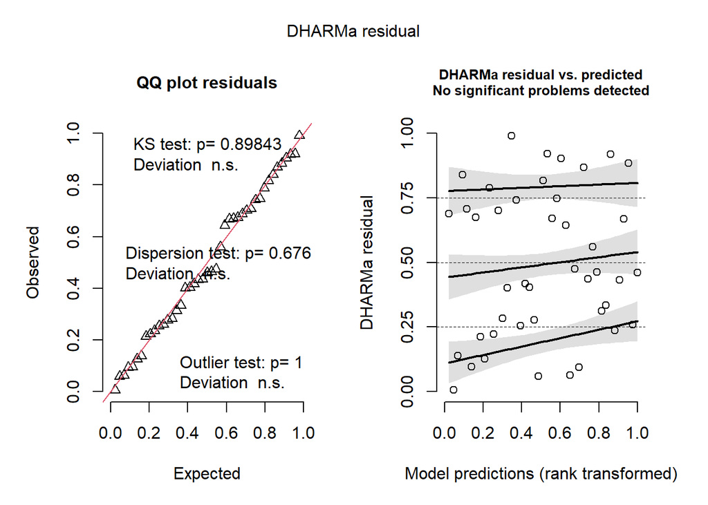

```r
library(DHARMa)
## Simulando os resíduos
resid_sim_1 <- simulateResiduals (b399_med_dist_eucl_clumpy, n=1000)
plot(resid_sim_1)
```

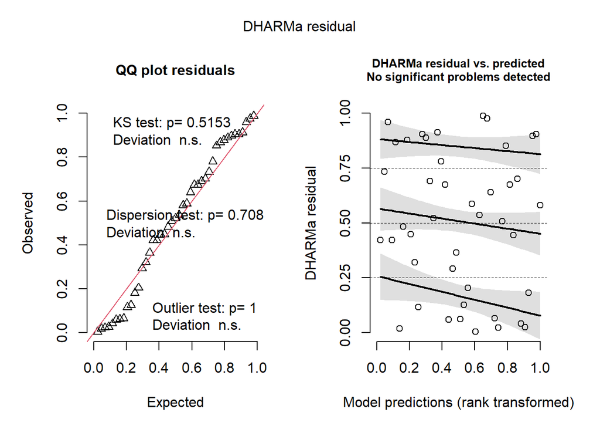

```r
resid_sim_2 <- simulateResiduals (b399_dens_frags_med_dist_eucl_clumpy, n=1000)
plot(resid_sim_2)
```

Aparentemente, ambos modelos estão bem ajustados. Podemos fazer uma análise mais minuciosa dos resíduos usando a função `check_model()` do pacote *performance*:

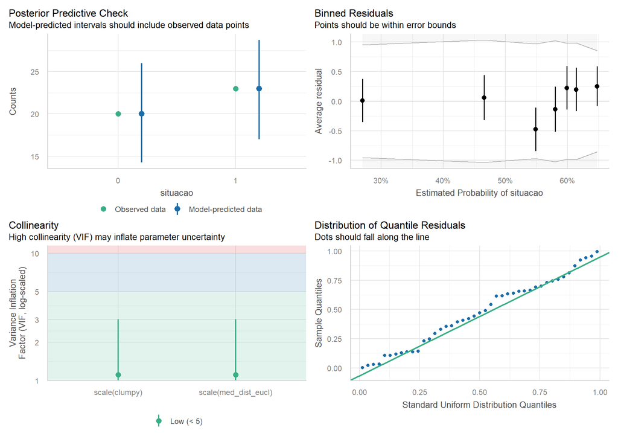

```r
library(performance)
check_model(b399_med_dist_eucl_clumpy)
```

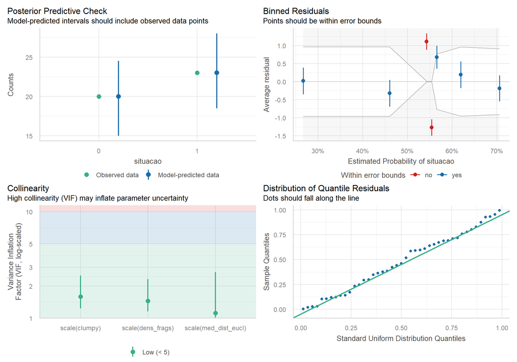

```r
check_model(b399_dens_frags_med_dist_eucl_clumpy)
```

Em geral, os modelo estão bem ajustados, apesar da falha pontual no ‘binned residuals’ para o segundo modelo.

Este último gráfico mostra que as probabilidades médias preditas (próximo de 50% e 60%) o modelo não foi bem calibrado, uma vez que há resíduos fora da banda. Isso pode sugerir variáveis omitidas ou má especificação da função de ligação.

## 1.6 Analisando os resultados

Por se tratar de um modelo logístico, todos os parâmetros estão expressos na escala logit e são interpretados sob a forma de *razão de chance*. Esses parâmetros podem ser transformados em probabilidades convertendo-os para escala natural conforme:

$$p = \frac{1}{1 +
exp(-\eta)}$$

```r
summary(b399_med_dist_eucl_clumpy)
```

```
##
## Call:
## glm(formula = f, family = binomial(link = "logit"), data = data)
##
## Coefficients:
##                      Estimate Std. Error z value Pr(>|z|)
## (Intercept)            0.1195     0.3185   0.375    0.708
## scale(med_dist_eucl)  -0.4901     0.3831  -1.279    0.201
## scale(clumpy)         -0.1372     0.3384  -0.405    0.685
##
## (Dispersion parameter for binomial family taken to be 1)
##
##     Null deviance: 59.401  on 42  degrees of freedom
## Residual deviance: 56.633  on 40  degrees of freedom
##   (41 observations deleted due to missingness)
## AIC: 62.633
##
## Number of Fisher Scoring iterations: 4
```

Avaliando individualmente os valores estimados para cada covariável, observamos que:

- `Intercept` (0.1195): representa a probabilidade de presença do guigó quando todas as covariáveis (nesse caso, média da distância euclidiana e clumpiness index) estão na média (que é 0, pois estão padronizadas).

  Convertendo para probabilidades, temos: $p = \frac{1}{1+exp(-0.1195))} \approx 0.53$
- `scale(med_dist_eucl)`: O coeficiente é negativo, ou seja, quanto maior a distância euclidiana média ao vizinho mais próximo, menor a probabilidade de ocorrência da espécie. Não é estatisticamente significativo (p = 0.201), então não podemos afirmar isso com confiança, mas o efeito sugere tendência.

  Convertendo para probabilidades, temos: $p = \frac{1}{1+exp(-1 \times(0.1195 - 0.4901))} \approx 0.41$

  Convertendo para probabilidades, temos: $p = \frac{1}{1+exp(-1 \times (0.1195 - 0.1372))} \approx 0.50$

  Quando o clumpiness index (indicie de agregação dos fragmentos) é 1 desvio padrão acima da média, a chance de presença do guigó é cerca de 50%, ou seja, um pouco menor do que quando a média é 0 (intercepto) e maior do que quando a distância média ao vizinho mais próximo é 1 desvio padrão acima da média.

# 2 GLM para dados discretos

## 2.1 Introdução

Dados de abundância são tipicamente contagens inteiras (0,1,2,3, …) e exigem modelos que lidem com sua natureza discreta e não-negativa. Os modelos lineares generalizados (GLMs) com família de distribuição adequada, normalmente Poisson ou Binomial Negativa, são a primeira escolha. Em Ecologia, as contagens costumam apresentar sobredispersão (variância > média) e/ou excesso de zeros, casos em que a família Poisson simples pode ser inadequada.

Aqui modelamos a abundância de *Callicebus barbarabrownae* em 30 fragmentos medidos por playback, esperando relacioná-la a atributos da paisagem (e.g. % de mata no entorno, tamanho do fragmento, isolamento, conectividade, matriz dominante, etc.).

Vejamos as informações contidas no banco de dados:

```r
dados <- read.csv("discreta/dados_cap2.csv")
```

```r
str(dados)
```

```
## 'data.frame':    300 obs. of  14 variables:
##  $ ID              : chr  "ID01" "ID01" "ID01" "ID01" ...
##  $ buffer          : chr  "buffer1266" "buffer1555" "buffer1844" "buffer2133" ...
##  $ n_groups        : int  3 3 3 3 3 3 3 3 3 3 ...
##  $ area_frag       : num  88.4 88.4 88.4 88.4 88.4 ...
##  $ prop_florest    : num  31.6 25 21.1 21.3 21.2 ...
##  $ dens_frags      : num  3.97 3.29 4.22 4.13 4.07 ...
##  $ media_area_frags: num  7.96 7.58 5.01 5.15 5.2 ...
##  $ med_dist_eucl   : num  105 114 123 123 127 ...
##  $ pcore           : num  22.3 16.4 13.2 13.1 12.7 ...
##  $ dens_borda      : num  52 48.3 45 45.9 48.1 ...
##  $ shape_mn        : num  1.58 1.67 1.54 1.58 1.58 ...
##  $ iagreg          : num  89.4 87.2 85.4 84.5 83.8 ...
##  $ clumpy          : num  0.853 0.835 0.82 0.814 0.803 ...
##  $ coesao          : num  96 95 93.9 93.3 93.4 ...
```

`dados$ID` representa a identidade de cada paisagem estudada. Ao todo, o banco de dados tem 30 paisagens distintas.

```r
length(unique(dados$ID))
```

```
## [1] 30
```

A variável `dados$buffer` indica o tamanho (raio) considerado para cada paisagem. Em estudos de ecologia da paisagem, é recomendável que o tamanho da paisagem seja definido a partir de uma análise de escala do efeito, a fim de identificar a escala na qual a variável dependente é melhor explicada pelas variáveis independentes do modelo. No presente conjunto de dados, cada paisagem foi avaliada em 10 tamanhos de buffer diferentes.

```r
table(dados$buffer) #cada buffer é repetido 30 vezes (que é o número total de paisagens)
```

```
##
## buffer1266 buffer1555 buffer1844 buffer2133 buffer2422 buffer2711 buffer3000
##         30         30         30         30         30         30         30
##  buffer399  buffer688  buffer977
##         30         30         30
```

```r
#ou:
table(unique(dados[, c("ID", "buffer")])$ID) #cada paisagem contem 10 tamanhos de buffer
```

```
##
## ID01 ID02 ID03 ID04 ID05 ID07 ID10 ID11 ID14 ID15 ID16 ID17 ID21 ID23 ID24 ID33
##   10   10   10   10   10   10   10   10   10   10   10   10   10   10   10   10
## ID35 ID40 ID45 ID46 ID57 ID62 ID64 ID66 ID78 ID79 ID80 ID82 ID85 ID87
##   10   10   10   10   10   10   10   10   10   10   10   10   10   10
```

A variável `dados$n_groups`, será nossa variável resposta, a abundância de grupos no fragmento central da paisagem. Como temos 30 paisagens ao todo, possuímos também 30 fragmentos centrais cuja a abundância de *Callicebus barbarabrownae* foi medida.

```r
summary(unique(dados[, c("ID", "n_groups")])$n_groups)
```

```
##    Min. 1st Qu.  Median    Mean 3rd Qu.    Max.
##   0.000   1.250   3.000   2.967   4.000  11.000
```

A abundância de *Callicebus barbarabrownae* variou de 0 a 11 grupos por fragmento. 75% dos fragmentos possui abundâncias de 0 a 4 grupos por fragmento. Vamos olhara para a distribuição de frequênicias da nossa variável resposta:

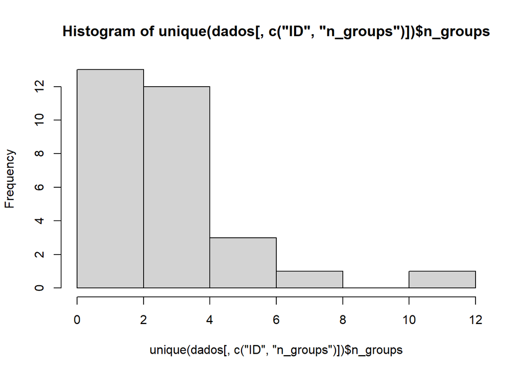

```r
hist(unique(dados[, c("ID", "n_groups")])$n_groups)
```

A variável `dados$area_frag` representa a área de cada fragmento florestal (em hectares) onde a densidade de grupos foi estimada. No conjunto de dados, a área dos fragmentos variou amplamente, entre 2 e 316 hectares.

```r
summary(dados$area_frag)
```

```
##    Min. 1st Qu.  Median    Mean 3rd Qu.    Max.
##   2.237  24.611  86.870  92.839 138.974 316.241
```

Como a relação entre a área do fragmento e a abundância de primatas é amplamente reconhecida como positiva, essa variável é um importante fator a ser considerado na modelagem.

Embora a área pudesse ser incorporada na variável resposta, por exemplo, expressando a abundância como número de grupos por hectare (densidade), isso geraria uma resposta contínua, o que não é o foco desta parte do relatório, que foca na análise de dados discretos (contagens). Assim, a área será incluída no modelo como um offset, termo que ajusta a expectativa da variável resposta proporcionalmente ao tamanho da área amostrada, permitindo controlar o efeito da variação na área dos fragmentos sobre o número observado de grupos. Dessa forma, o modelo estima a abundância esperada por unidade de área, sem a necessidade de transformar diretamente a variável resposta.

No R, o offset é especificado dentro da função de ajuste do modelo, geralmente como offset(log(area_frag)). O uso do logaritmo garante que o ajuste seja feito na mesma escala do preditor linear (no caso de modelos Poisson ou quasi-Poisson), permitindo interpretar o efeito da área como uma correção multiplicativa da taxa de ocorrência. Assim, o modelo estima a taxa de grupos por hectare, controlando adequadamente o efeito do esforço amostral associado à área de cada fragmento.

As outras informações do banco de dados (`dados[,5:14]`) são diferentes métricas da paisagem, calculadas a partir do pacote `landscapemetrics` (Hesselbarth et al., 2019) com base em imagens da Coleção 7 do MapBiomas, referentes ao ano de 2021. Onde:

- `dados$prop_florest` é a proporção de floresta na paisagem (em %);
- `dados$dens_frags` é a densidade de fragmentos da paisagem (frags/100 ha);
- `dados$media_area_frags` é a média da área de todos os fragmentos da paisagem (ha);
- `dados$med_dist_eucl` é a média da distância euclidiana do vizinho mais próximo (calculada para cada fragmento da paisagem e expressa em metros);
- `dados$pcore` diferente das outras métricas, essa é calculada apenas para o fragmento em que foi registrada a presença ou ausência da espécie (fragmento central da paisagem). Mede a área central do fragmento (em hectares), desconsiderando a borda;
- `dados$dens_borda` é a densidade de borda dos fragmentos da paisagem (m/ha);
- `dados$shape_mn` é um índice que mede o formato médio dos fragmentos da paisagem. Seu valor é sempre maior ou igual a 1; quanto mais próximo de 1, mais próximo de uma forma quadrada é o fragmento, e quanto mais distante de 1, mais complexo é o formato;
- `dados$iagreg` é uma métrica de agregação, que indica o grau de agrupamento entre os fragmentos de floresta, variando de 0% (fragmentos mais isolados) a 100% (fragmentos mais próximos e conectados);
- `dados$clumpy` é o índice de aglomeração, que mede o padrão de distribuição espacial dos fragmentos. Valores próximos de 1 indicam paisagens altamente agregadas, enquanto valores próximos de 0 indicam uma distribuição mais aleatória;
- `dados$coesao` é o índice de coesão, que expressa o grau de conectividade física entre fragmentos de floresta na paisagem (em %). Quanto maior o valor, mais conectada e estruturalmente coesa é a paisagem.

## 2.2 Checando multicolinearidade

Como possuímos várias variáveis independentes, o primeiro passo é selecionar aquelas que não estejam fortemente correlacionadas entre si. Como temos 10 diferentes tamanhos de paisagem, o ideal seria avaliar cuidadosamente as correlações entre as métricas em cada tamanho de buffer.

A seguir, apresentarei *os resultados dos testes de correlação realizados para a maior paisagem (buffer com raio de 3000 m)*.

Para verificar a multicolinearidade entre as métricas de paisagem, calculei as correlações pareadas entre todas as variáveis utilizando o coeficiente de correlação de Pearson, por meio da função `cor()` do R.

```r
b3000 <- subset(dados, buffer== "buffer3000") #selecionando apenas os buffers de raio de 3000m

# Correlation matrix
nrow(b3000) #checando se estão as 30 paisagens
```

```
## [1] 30
```

```r
names(b3000) #checando as colunas que contém minhas variáveis independentes
```

```
##  [1] "ID"               "buffer"           "n_groups"         "area_frag"
##  [5] "prop_florest"     "dens_frags"       "media_area_frags" "med_dist_eucl"
##  [9] "pcore"            "dens_borda"       "shape_mn"         "iagreg"
## [13] "clumpy"           "coesao"
```

```r
M <- cor(b3000[5:14], use = "complete.obs")
round(M,2)
```

```
##                  prop_florest dens_frags media_area_frags med_dist_eucl pcore
## prop_florest             1.00      -0.03             0.89         -0.78  0.98
## dens_frags              -0.03       1.00            -0.42         -0.30 -0.12
## media_area_frags         0.89      -0.42             1.00         -0.57  0.93
## med_dist_eucl           -0.78      -0.30            -0.57          1.00 -0.71
## pcore                    0.98      -0.12             0.93         -0.71  1.00
## dens_borda               0.85       0.28             0.61         -0.84  0.74
## shape_mn                 0.28      -0.30             0.30         -0.37  0.19
## iagreg                   0.84      -0.14             0.79         -0.63  0.87
## clumpy                   0.41      -0.26             0.46         -0.24  0.50
## coesao                   0.80      -0.34             0.80         -0.51  0.79
##                  dens_borda shape_mn iagreg clumpy coesao
## prop_florest           0.85     0.28   0.84   0.41   0.80
## dens_frags             0.28    -0.30  -0.14  -0.26  -0.34
## media_area_frags       0.61     0.30   0.79   0.46   0.80
## med_dist_eucl         -0.84    -0.37  -0.63  -0.24  -0.51
## pcore                  0.74     0.19   0.87   0.50   0.79
## dens_borda             1.00     0.45   0.57   0.06   0.65
## shape_mn               0.45     1.00   0.09  -0.17   0.38
## iagreg                 0.57     0.09   1.00   0.84   0.77
## clumpy                 0.06    -0.17   0.84   1.00   0.49
## coesao                 0.65     0.38   0.77   0.49   1.00
```

Aqui, adotei o limiar de |r| > 0.7 para indicar correlação forte. Quando duas métricas apresentaram correlação elevada, e uma delas era `dados$prop_florest`, essa última foi priorizada para ser mantida, considerando sua importância ecológica para a espécie-alvo.

Dessa forma, pelos valores de correlação de Pearson, as métricas que não estão correlacionadas com `dados$prop_florest` e que foram selecionadas para explicar a abundânica da espécie nas paisagens geradas pelo buffer de 3000m, são:

- `dados$dens_frags`;
- `dados$shape_mn`;
- `dados$clumpy`;
- além de `dados$prop_florest`.

O resultado das análises de multicolinearidade para os demais tamanhos de buffer no código a seguir, mas, para não alongar o relatório, deixei o resultado em formato de comentário no própio código.

```r
# Checando as correlações para os outros tamanhos de paisagem

## subsets para os outros tamanhos
b399 <- subset(dados, buffer== "buffer399")
b688 <- subset(dados, buffer== "buffer688")
b977 <- subset(dados, buffer== "buffer977")
b1266 <- subset(dados, buffer== "buffer1266")
b1555 <- subset(dados, buffer== "buffer1555")
b1844 <- subset(dados, buffer== "buffer1844")
b2133 <- subset(dados, buffer== "buffer2133")
b2422 <- subset(dados, buffer== "buffer2422")
b2711 <- subset(dados, buffer== "buffer2711")

# Correlação métricas b399
M <- cor(b399[5:14], use = "complete.obs")
round(M,2)
# Priorizando a prop_florest, ficam: dens_frags, shape_mn e clumpy

# Correlação métricas b688
M <- cor(b688[5:14], use = "complete.obs")
round(M,2)
# Priorizando a prop_florest, ficam: dens_frags, med_dist_eucl, shape_mn e clumpy

# Correlação métricas b977
M <- cor(b977[5:14], use = "complete.obs")
round(M,2)
# Priorizando a prop_florest, ficam: dens_frags, med_dist_eucl, dens_borda, shape_mn e clumpy

# Correlação métricas b1266
M <- cor(b1266[5:14], use = "complete.obs")
round(M,2)
# Priorizando a prop_florest, ficam: dens_frags, med_dist_eucl, dens_borda, shape_mn e clumpy.
#Obs: media area frags podia até entrar mas ela tem uma correlação relativamente alta (maior que |0.6|) com várias métricas, por isso não inclui

# Correlação métricas b1555
M <- cor(b1555[5:14], use = "complete.obs")
round(M,2)
# Priorizando a prop_florest, ficam: dens_frags, med_dist_eucl, shape_mn e clumpy

# Correlação métricas b1844
M <- cor(b1844[5:14], use = "complete.obs")
round(M,2)
# Priorizando a prop_florest, ficam: dens_frags, shape_mn e clumpy

# Correlação métricas b2133
M <- cor(b2133[5:14], use = "complete.obs")
round(M,2)
# Priorizando a prop_florest, ficam: dens_frags, shape_mn e clumpy

# Correlação métricas b2422
M <- cor(b2422[5:14], use = "complete.obs")
round(M,2)
# Priorizando a prop_florest, ficam: dens_frags, shape_mn e clumpy

# Correlação métricas b2711
M <- cor(b2711[5:14], use = "complete.obs")
round(M,2)
# Priorizando a prop_florest, ficam: dens_frags, shape_mn e clumpy
```

## 2.3 Gerando modelos

Como para cada tamanho de buffer foram selecionadas métricas diferentes, irei gerar os modelos para cada um deles. Primeiro, utilizarei GLMs com distribuição Poisson e função de ligação log.

Modelos nulos:

```r
### Nulo ----
b399_null_model <- glm(n_groups ~ 1 + offset(log(area_frag)), family = poisson(link = "log"), data = b399)
b688_null_model <- glm(n_groups ~ 1 + offset(log(area_frag)), family = poisson(link = "log"), data = b688)
b977_null_model <- glm(n_groups ~ 1 + offset(log(area_frag)), family = poisson(link = "log"), data = b977)
b1266_null_model <- glm(n_groups ~ 1 + offset(log(area_frag)), family = poisson(link = "log"), data = b1266)
b1555_null_model <- glm(n_groups ~ 1 + offset(log(area_frag)), family = poisson(link = "log"), data = b1555)
b1844_null_model <- glm(n_groups ~ 1 + offset(log(area_frag)), family = poisson(link = "log"), data = b1844)
b2133_null_model <- glm(n_groups ~ 1 + offset(log(area_frag)), family = poisson(link = "log"), data = b2133)
b2422_null_model <- glm(n_groups ~ 1 + offset(log(area_frag)), family = poisson(link = "log"), data = b2422)
b2711_null_model <- glm(n_groups ~ 1 + offset(log(area_frag)), family = poisson(link = "log"), data = b2711)
b3000_null_model <- glm(n_groups ~ 1 , family = poisson(link = "log"), data = b3000)
```

Como são muitos modelos (e combinações possíveis), uso uma função que gera todas combinações possíveis e salva cada modelo em um objeto:

```r
### Função para criar todos os modelos e gerar objetos separados
create_glm_models_objects_poisson <- function(data, vars, prefix){
  model_names <- c()

  for(n in 1:length(vars)){
    combos <- combn(vars, n, simplify = FALSE)

    for(i in seq_along(combos)){
      f <- as.formula(paste("n_groups ~", paste0("scale(", combos[[i]], ")", collapse = " + "), "+ offset(log(area_frag))"))

      model_name <- paste0(prefix, "_", paste(combos[[i]], collapse = "_"))
      model <- glm(f, family = poisson(link = "log"), data = data)
      assign(model_name, model, envir = .GlobalEnv)
      model_names <- c(model_names, model_name)
      message("Modelo criado: ", model_name)}}
  return(model_names)}
```

Modelos para os buffers de raios de: 399, 1844, 2133, 2422, 2711 e 3000 m

```r
### Variáveis preditoras
vars <- c("prop_florest", "dens_frags", "shape_mn", "clumpy")
modelos_399 <- create_glm_models_objects_poisson(b399, vars, "b399")
modelos_1844 <- create_glm_models_objects_poisson(b1844, vars, "b1844")
modelos_2133 <- create_glm_models_objects_poisson(b2133, vars, "b2133")
modelos_2422 <- create_glm_models_objects_poisson(b2422, vars, "b2422")
modelos_2711 <- create_glm_models_objects_poisson(b2711, vars, "b2711")
modelos_3000 <- create_glm_models_objects_poisson(b3000, vars, "b3000")
```

Modelos para os buffers de raios de: 688 e 1555 m

```r
### Variáveis preditoras
vars <- c("prop_florest", "dens_frags", "med_dist_eucl", "shape_mn", "clumpy")
modelos_688 <- create_glm_models_objects_poisson(b688, vars, "b688")
modelos_1555 <- create_glm_models_objects_poisson(b1555, vars, "b1555")
```

Modelos para os buffers de raios de: 977 e 1266 m

```r
### Variáveis preditoras
vars <- c("prop_florest", "dens_frags", "med_dist_eucl", "dens_borda", "shape_mn", "clumpy")
modelos_977 <- create_glm_models_objects_poisson(b977, vars, "b977")
modelos_1266 <- create_glm_models_objects_poisson(b1266, vars, "b1266")
```

Agora, preciso salvar todos esses modelos em um único objeto para então gerar uma tabela e compará-los pelo AIC.

```r
todos_modelos_nomes <- c("b399_null_model", "b688_null_model", "b977_null_model", "b1266_null_model","b1555_null_model", "b1844_null_model", "b2133_null_model", "b2422_null_model", "b2711_null_model", "b3000_null_model", modelos_399, modelos_688, modelos_977, modelos_1266, modelos_1555, modelos_1844, modelos_2133, modelos_2422, modelos_2711, modelos_3000) #nomes

todos_modelos_lista <- lapply(todos_modelos_nomes, get) #criando lista com todos os modelos

names(todos_modelos_lista) <- todos_modelos_nomes # nomeando a lista para identificar os modelos

library("AICcmodavg") #pacote que uso para gerar tabela de AIC

modelos_AIC <- aictab(cand.set = todos_modelos_lista, modnames = todos_modelos_nomes)

modelos_AIC <- data.frame(modelos_AIC)

library(DT) #Pacote que encontrei para gerar tabela interativa

datatable(modelos_AIC, caption = "Tabela com AIC de todos modelos gerados", options = list(pageLength = 10, scrollX = TRUE))
```

|  | Modnames | K | AICc | Delta_AICc | ModelLik | AICcWt | LL | Cum.Wt |
| --- | --- | --- | --- | --- | --- | --- | --- | --- |
| 10 | b3000_null_model | 1 | 132.5415431763624 | 0 | 1 | 0.9391931896945688 | -65.19934301675261 | 0.9391931896945688 |
| 32 | b688_prop_florest_med_dist_eucl | 3 | 141.9394520847866 | 9.397908908424284 | 0.009104791603415749 | 0.008551158267516365 | -67.46972604239332 | 0.9477443479620852 |
| 54 | b688_prop_florest_med_dist_eucl_shape_mn_clumpy | 5 | 142.375339445393 | 9.833796269030643 | 0.00732180691971274 | 0.006876591195252774 | -64.82403335906014 | 0.9546209391573379 |
| 45 | b688_prop_florest_med_dist_eucl_clumpy | 4 | 142.383847696543 | 9.842304520180647 | 0.00729072519329932 | 0.006847399449481339 | -66.32235863088019 | 0.9614683386068192 |
| 44 | b688_prop_florest_med_dist_eucl_shape_mn | 4 | 144.1994811003968 | 11.65793792403443 | 0.002941107811369034 | 0.002762268426595295 | -67.23017533280708 | 0.9642306070334146 |
| 41 | b688_prop_florest_dens_frags_med_dist_eucl | 4 | 144.3118308104821 | 11.7702876341198 | 0.002780446320954681 | 0.002611376248951956 | -67.28635018784978 | 0.9668419832823665 |
| 67 | b977_prop_florest_clumpy | 3 | 144.4435599257602 | 11.9020167493978 | 0.002603214179149937 | 0.002444921028373957 | -68.76024150134161 | 0.9692869043107405 |
| 56 | b688_prop_florest_dens_frags_med_dist_eucl_shape_mn_clumpy | 6 | 144.6342193992405 | 12.0926762228782 | 0.002366512062504545 | 0.002222612012434316 | -64.31710969962027 | 0.9715095163231747 |
| 87 | b977_prop_florest_shape_mn_clumpy | 4 | 144.6975697735257 | 12.15602659716339 | 0.002292727095412428 | 0.002153313673839562 | -67.54878488676287 | 0.9736628299970144 |
| 86 | b977_prop_florest_dens_borda_clumpy | 4 | 144.7961250611115 | 12.25458188474911 | 0.002182485438137861 | 0.002049775460106646 | -67.59806253055574 | 0.975712605457121 |

[output cut: 278 more lines]

A seguir, iremos analisar graficamente o ajuste do modelo:

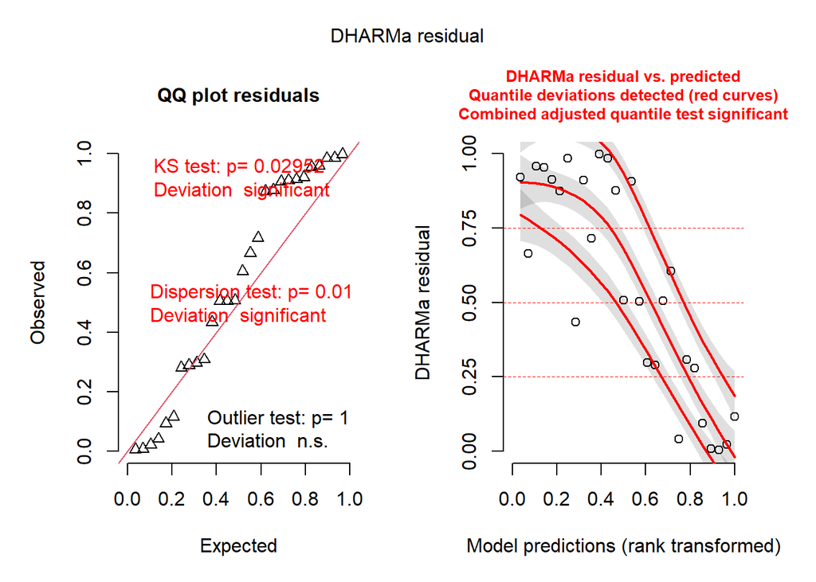

```r
library(DHARMa)
## Simulando os resíduos
resid_sim_1 <- simulateResiduals (b688_prop_florest_med_dist_eucl, n=1000)
plot(resid_sim_1)
```

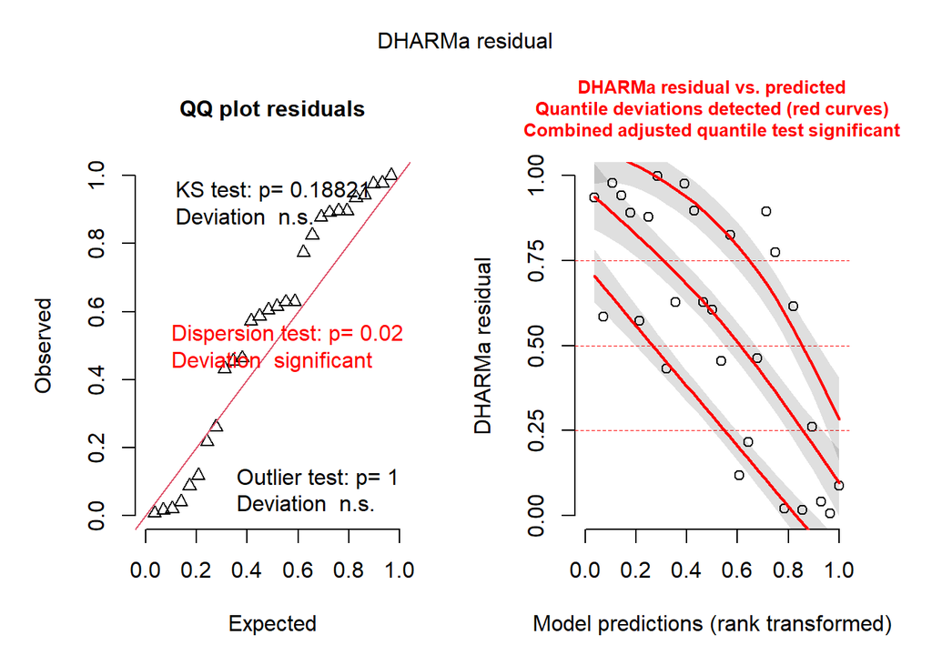

```r
resid_sim_2 <- simulateResiduals (b688_prop_florest_med_dist_eucl_shape_mn_clumpy, n=1000)
plot(resid_sim_2)
```

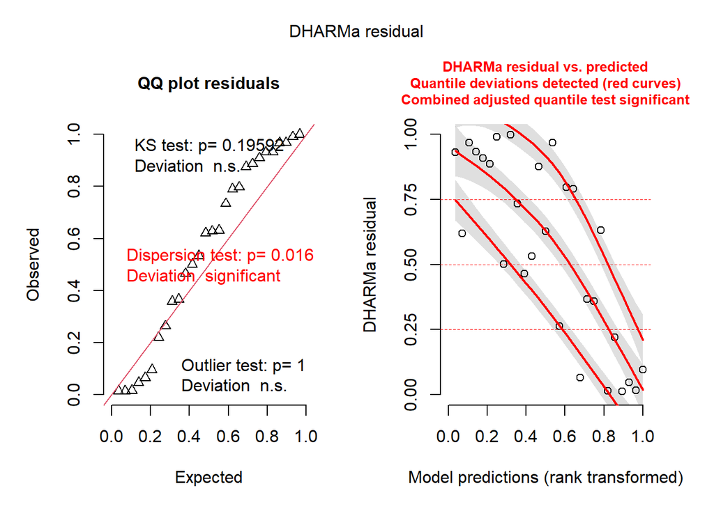

```r
resid_sim_3 <- simulateResiduals (b688_prop_florest_med_dist_eucl_clumpy, n=1000)
plot(resid_sim_3)
```

Aparentemente, ambos modelos não estão bem ajustados. Podemos avaliar também usando a função `check_model()` do pacote *performance*:

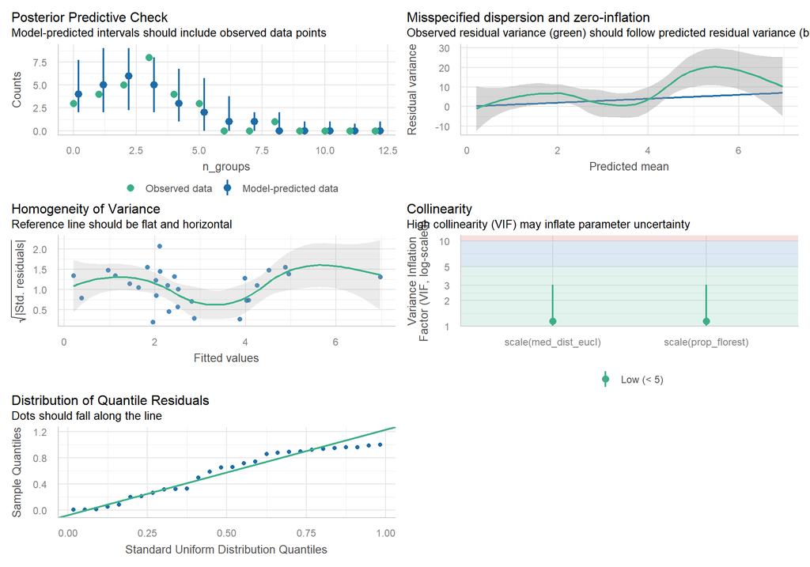

```r
library(performance)
check_model(b688_prop_florest_med_dist_eucl)
```

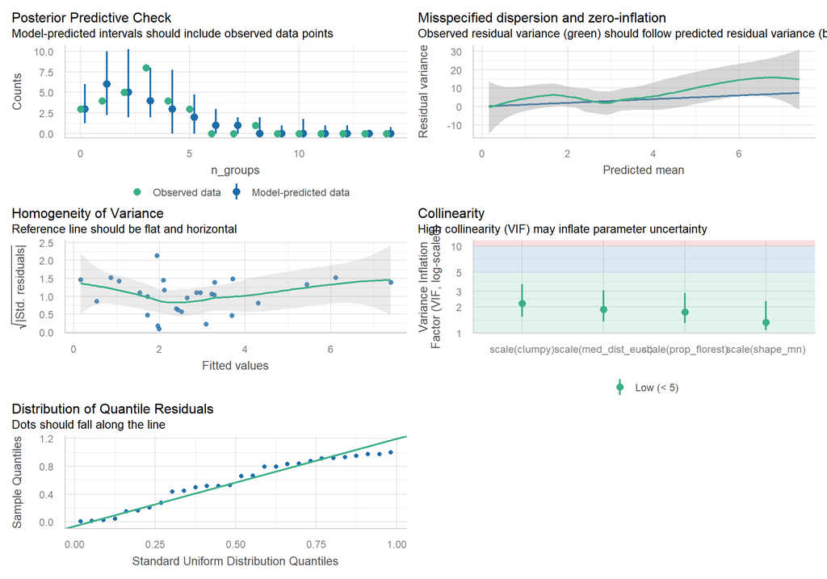

```r
check_model(b688_prop_florest_med_dist_eucl_shape_mn_clumpy)
```

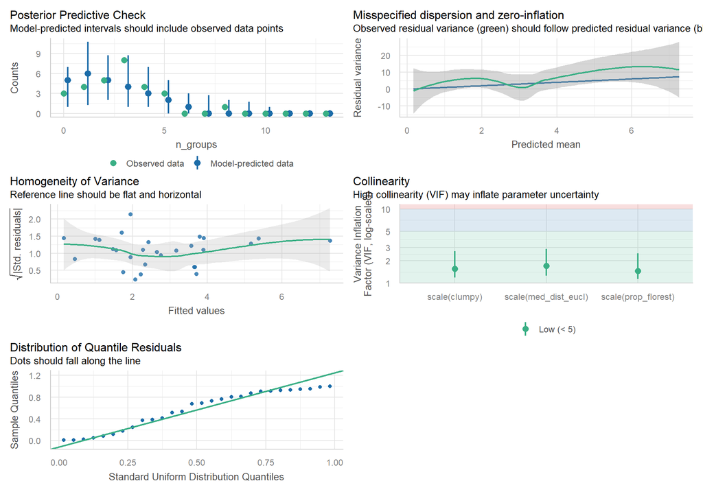

```r
check_model(b688_prop_florest_med_dist_eucl_clumpy)
```

```r
check_overdispersion(b688_prop_florest_med_dist_eucl)
```

```
## # Overdispersion test
##
##        dispersion ratio =   2.612
##   Pearson's Chi-Squared =  65.295
##                 p-value = < 0.001
```

```r
check_overdispersion(b688_prop_florest_med_dist_eucl_shape_mn_clumpy)
```

```
## # Overdispersion test
##
##        dispersion ratio =   2.699
##   Pearson's Chi-Squared =  62.073
##                 p-value = < 0.001
```

```r
check_overdispersion(b688_prop_florest_med_dist_eucl_clumpy)
```

```
## # Overdispersion test
##
##        dispersion ratio =   2.717
##   Pearson's Chi-Squared =  65.206
##                 p-value = < 0.001
```

Parece que os modelos não estão bem ajustados e com sobredispersão. Podemos tentar construir os modelos, agora usando a distribuição *binomial negativa*.

Para isso precisaremos do pacote MASS:

```r
library(MASS)
```

Modelos nulos:

```r
### Nulo ----
b399_null_model <- glm.nb(n_groups ~ 1 + offset(log(area_frag)), data = b399)
b688_null_model <- glm.nb(n_groups ~ 1 + offset(log(area_frag)), data = b688)
b977_null_model <- glm.nb(n_groups ~ 1 + offset(log(area_frag)), data = b977)
b1266_null_model <- glm.nb(n_groups ~ 1 + offset(log(area_frag)), data = b1266)
b1555_null_model <- glm.nb(n_groups ~ 1 + offset(log(area_frag)), data = b1555)
b1844_null_model <- glm.nb(n_groups ~ 1 + offset(log(area_frag)), data = b1844)
b2133_null_model <- glm.nb(n_groups ~ 1 + offset(log(area_frag)), data = b2133)
b2422_null_model <- glm.nb(n_groups ~ 1 + offset(log(area_frag)), data = b2422)
b2711_null_model <- glm.nb(n_groups ~ 1 + offset(log(area_frag)), data = b2711)
b3000_null_model <- glm.nb(n_groups ~ 1 + offset(log(area_frag)), data = b3000)
```

Como são muitos modelos (e combinações possíveis), uso uma função que gera todas combinações possíveis e salva cada modelo em um objeto:

```r
### Função para criar todos os modelos e gerar objetos separados
create_glm_models_objects_binom_neg <- function(data, vars, prefix){
  if(missing(prefix) || prefix == "")
    stop("Por favor, forneça um prefixo válido (ex: prefix = 'nb').")
  if(length(vars) == 0)
    stop("O vetor 'vars' está vazio.")
  model_names <- c()
  for(n in 1:length(vars)){
    combos <- combn(vars, n, simplify = FALSE)
    for(i in seq_along(combos)){
      f <- as.formula(paste("n_groups ~", paste0("scale(", combos[[i]], ")", collapse = " + "), "+ offset(log(area_frag))"))
      model_name <- paste0(prefix, "_", paste(combos[[i]], collapse = "_"))
      message("Criando modelo: ", model_name)
      model <- MASS::glm.nb(f, data = data)
      assign(model_name, model, envir = .GlobalEnv)
      model_names <- c(model_names, model_name)}}
    return(model_names)}
```

Modelos para os buffers de raios de: 399, 1844, 2133, 2422, 2711 e 3000 m

```r
### Variáveis preditoras
vars <- c("prop_florest", "dens_frags", "shape_mn", "clumpy")
modelos_399 <- create_glm_models_objects_binom_neg(b399, vars, "b399")
modelos_1844 <- create_glm_models_objects_binom_neg(b1844, vars, "b1844")
modelos_2133 <- create_glm_models_objects_binom_neg(b2133, vars, "b2133")
modelos_2422 <- create_glm_models_objects_binom_neg(b2422, vars, "b2422")
modelos_2711 <- create_glm_models_objects_binom_neg(b2711, vars, "b2711")
modelos_3000 <- create_glm_models_objects_binom_neg(b3000, vars, "b3000")
```

Modelos para os buffers de raios de: 688 e 1555 m

```r
### Variáveis preditoras
vars <- c("prop_florest", "dens_frags", "med_dist_eucl", "shape_mn", "clumpy")
modelos_688 <- create_glm_models_objects_binom_neg(b688, vars, "b688")
modelos_1555 <- create_glm_models_objects_binom_neg(b1555, vars, "b1555")
```

Modelos para os buffers de raios de: 977 e 1266 m

```r
### Variáveis preditoras
vars <- c("prop_florest", "dens_frags", "med_dist_eucl", "dens_borda", "shape_mn", "clumpy")
modelos_977 <- create_glm_models_objects_binom_neg(b977, vars, "b977")
modelos_1266 <- create_glm_models_objects_binom_neg(b1266, vars, "b1266")
```

Agora, preciso salvar todos esses modelos em um único objeto para então gerar uma tabela e compará-los pelo AIC.

```r
todos_modelos_nb_nomes <- c("b399_null_model", "b688_null_model", "b977_null_model", "b1266_null_model","b1555_null_model", "b1844_null_model", "b2133_null_model", "b2422_null_model", "b2711_null_model", "b3000_null_model", modelos_399, modelos_688, modelos_977, modelos_1266, modelos_1555, modelos_1844, modelos_2133, modelos_2422, modelos_2711, modelos_3000) #nomes

todos_modelos_nb_lista <- lapply(todos_modelos_nb_nomes, get) #criando lista com todos os modelos

names(todos_modelos_nb_lista) <- todos_modelos_nb_nomes # nomeando a lista para identificar os modelos

aic_vals <- sapply(todos_modelos_nb_lista, AICcmodavg::AICc)
k_vals <- sapply(todos_modelos_nb_lista, function(m) attr(logLik(m), "df"))
delta_aic <- aic_vals - min(aic_vals)

aic_table <- data.frame(AICc = sapply(todos_modelos_nb_lista, AICcmodavg::AICc),Delta_AICc = round(delta_aic, 2), K = k_vals)

# Ordenar do melhor para o pior
aic_table <- aic_table[order(aic_table$AICc), ]

library(DT) #Pacote que encontrei para gerar tabela interativa

datatable(aic_table, caption = "Tabela com AIC de todos modelos gerados", options = list(pageLength = 10, scrollX = TRUE))
```

|  | AICc | Delta_AICc | K |
| --- | --- | --- | --- |
| b688_prop_florest_med_dist_eucl | 133.5048209774677 | 0 | 4 |
| b688_prop_florest_med_dist_eucl_clumpy | 135.8343186071466 | 2.33 | 5 |
| b688_prop_florest_med_dist_eucl_shape_mn | 136.1449093381446 | 2.64 | 5 |
| b688_prop_florest_dens_frags_med_dist_eucl | 136.2595075935489 | 2.75 | 5 |
| b688_prop_florest_med_dist_eucl_shape_mn_clumpy | 137.6459322289475 | 4.14 | 6 |
| b688_med_dist_eucl_shape_mn_clumpy | 138.7663370628783 | 5.26 | 5 |
| b688_prop_florest_dens_frags_med_dist_eucl_clumpy | 138.9135283051936 | 5.41 | 6 |
| b688_med_dist_eucl_clumpy | 139.3083847417908 | 5.8 | 4 |
| b688_prop_florest_dens_frags_med_dist_eucl_shape_mn | 139.3901587140315 | 5.89 | 6 |
| b688_dens_frags_med_dist_eucl_clumpy | 139.6444112941751 | 6.14 | 5 |

[output cut: 278 more lines]

Agora, parece que o melhor modelo é b688_prop_florest_med_dist_eucl, vamos checar o ajuste do modelo.

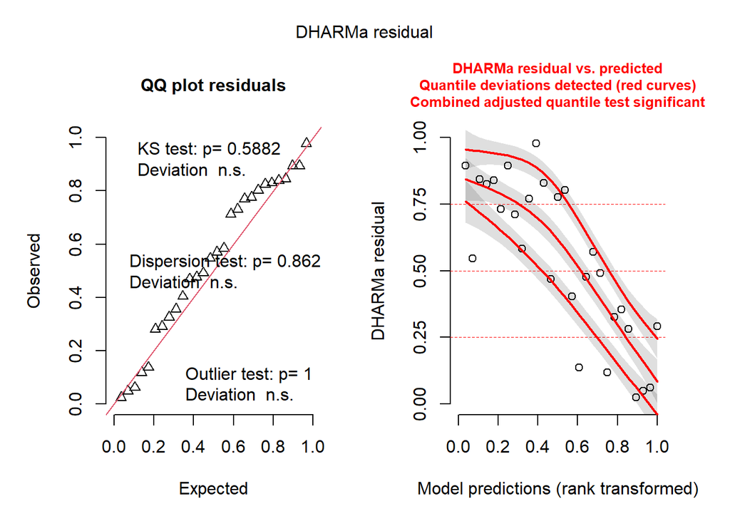

```r
library(DHARMa)
## Simulando os resíduos
resid_sim_1 <- simulateResiduals (b688_prop_florest_med_dist_eucl, n=1000)
plot(resid_sim_1)
```

```r
check_overdispersion(b688_prop_florest_med_dist_eucl)
```

```
## # Overdispersion test
##
##  dispersion ratio = 0.818
##           p-value =  0.84
```

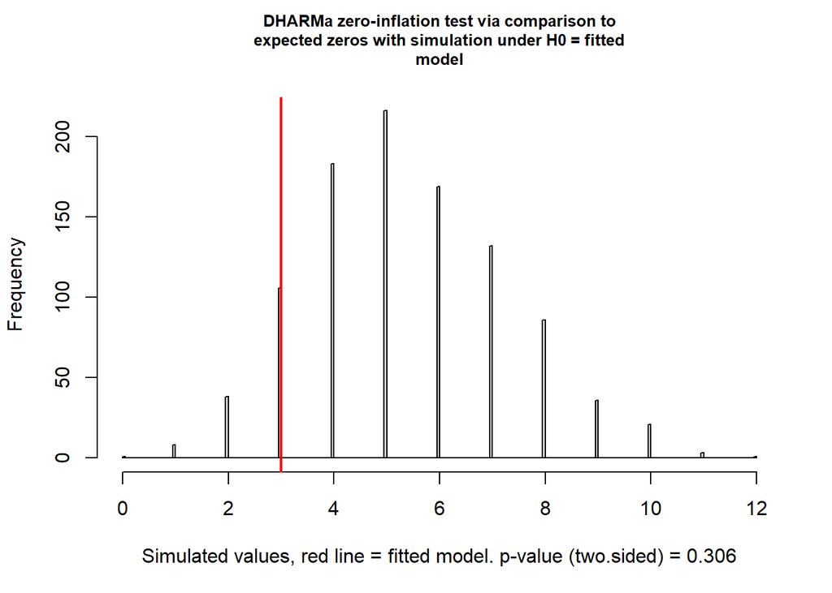

```
##
##  DHARMa zero-inflation test via comparison to expected zeros with
##  simulation under H0 = fitted model
##
## data:  simulationOutput
## ratioObsSim = 0.55361, p-value = 0.306
## alternative hypothesis: two.sided
```

```r
testZeroInflation(resid_sim_1) #não há evidência de inflação de 0
```

O modelo não está subestimando ou superestimando zeros — a estrutura de zeros dos seus dados está bem representada pelo modelo. Parece que o modelo continua com alguns problemas nos resíduos, mas já não está com sobredispersão.

## 2.4 Analisando os resultados

```r
summary(b688_prop_florest_med_dist_eucl)
```

```
##
## Call:
## MASS::glm.nb(formula = f, data = data, init.theta = 2.375972067,
##     link = log)
##
## Coefficients:
##                      Estimate Std. Error z value Pr(>|z|)
## (Intercept)           -2.9966     0.1680 -17.838  < 2e-16 ***
## scale(prop_florest)   -0.7571     0.1961  -3.860 0.000113 ***
## scale(med_dist_eucl)  -0.1485     0.1895  -0.784 0.433172
## ---
## Signif. codes:  0 '***' 0.001 '**' 0.01 '*' 0.05 '.' 0.1 ' ' 1
##
## (Dispersion parameter for Negative Binomial(2.376) family taken to be 1)
##
##     Null deviance: 47.012  on 27  degrees of freedom
## Residual deviance: 30.587  on 25  degrees of freedom
##   (2 observations deleted due to missingness)
## AIC: 131.77
##
## Number of Fisher Scoring iterations: 1
##
##
##               Theta:  2.38
##           Std. Err.:  1.13
##
##  2 x log-likelihood:  -123.766
```

A proporção de floresta teve um efeito negativo e significativo sobre a abundância de *Callicebus barbarabrownae* (β = -0.76, p < 0.001), enquanto a distância euclidiana média entre fragmentos também apresentou efeito negativo, porém não significativo (β = -0.15, p = 0.43). Assim, paisagens com maior cobertura florestal (e fragmentos mais distantes entre si) tendem a apresentar menor abundância da espécie. Esse é um resultado diferente do esperado, uma vez que essa espécie é altamente dependente de florestas e paisagens com maior cobertura florestal são melhores. Porém, a detecção da espécie em paisagens com maiores coberturas florestais (e fragmentos maiores) pode ser menor. Além disso, o modelo ainda não está completamentamente ajustado e outras variáveis poderiam ajudar a explicar a variação na abundância de *Callicebus barbarabrownae* (como por exemplo a estrutura local dos fragmentos em que foi amostrado).

# 3 GLM para dados contínuos

## 3.1 Introdução

Dados contínuos são aqueles que podem assumir qualquer valor dentro de um intervalo, como medidas de densidade, altura ou área.

Durante meu mestrado, verifiquei que a melhor escala espacial para explicar a densidade atual de *Callicebus barbarabrownae* (varíavel contínua) era a de buffers com 1.844 m de raio em torno dos fragmentos. A densidade da espécie nos 30 fragmentos amostrados é maior do que densidades registradas na literatura para essa espécie e para o gênero como um todo. Além disso, as maiores densidades foram registradas em paisagens com cobertura florestal baixa a mediana e com fragmentos pouco agregados.

Esses padrões sugerem que a espécie pode estar vivenciando um débito de extinção. Por isso, o objetivo desta seção do relatório é avaliar como a estrutura passada da paisagem explica a densidade atual de *Callicebus barbarabrownae*. Minha hipótese é que a estrutura passada da paisagem seja um melhor preditor da densidade atual, uma vez que:

- *Callicebus barbarabrownae* é altamente dependente de florestas e ocorre em regiões com forte pressão de conversão de habitat;
- Por ser um primata de porte médio, não utiliza a matriz e possui longos tempos de geração;
- Suas dinâmicas comportamentais, como dispersão de juvenis e territorialidade, dependem da conectividade entre fragmentos.

Dessa forma, esses primatas podem não reagir imediatamente à perda de habitat, e densidades atuais elevadas em paisagens com baixa cobertura florestal e fragmentos pouco próximos podem ser reflexos de uma estrutura passada da paisagem.

## 3.2 Gerando modelos

```r
### Manipulando os dados ----
dados <- read.csv("D:/doutorado/cap_3/metricas/dados_cap3_doc.csv")
dados$dens_groups <- dados$n_groups/dados$area_frag
str(dados)
```

```
## 'data.frame':    1170 obs. of  22 variables:
##  $ X              : int  1 2 3 4 5 6 7 8 9 10 ...
##  $ ID             : chr  "ID01" "ID01" "ID01" "ID01" ...
##  $ buffer         : int  1844 1844 1844 1844 1844 1844 1844 1844 1844 1844 ...
##  $ n_groups       : int  3 3 3 3 3 3 3 3 3 3 ...
##  $ area_frag      : num  88.4 88.4 88.4 88.4 88.4 ...
##  $ ano            : int  1985 1986 1987 1988 1989 1990 1991 1992 1993 1994 ...
##  $ lsm_c_ca       : num  536 527 438 358 327 ...
##  $ lsm_c_pland    : num  50.1 49.4 41 33.5 30.6 ...
##  $ lsm_c_np       : int  27 29 21 24 25 29 33 34 33 31 ...
##  $ lsm_c_pd       : num  2.53 2.72 1.97 2.25 2.34 ...
##  $ lsm_c_ai       : num  89.4 89.1 87.2 85.9 84.4 ...
##  $ lsm_c_clumpy   : num  0.787 0.785 0.784 0.788 0.775 ...
##  $ lsm_c_cohesion : num  98.7 98.7 98.3 97.6 97.4 ...
##  $ lsm_c_contig_mn: num  0.425 0.398 0.465 0.44 0.378 ...
##  $ lsm_c_contig_cv: num  68.5 74.3 66.1 71.4 74.4 ...
##  $ lsm_c_contig_sd: num  0.291 0.296 0.307 0.314 0.281 ...
##  $ lsm_c_enn_mn   : num  86.2 81.7 134.7 106 115.2 ...
##  $ lsm_c_enn_cv   : num  45.4 47.3 89.5 59.7 81 ...
##  $ lsm_c_enn_sd   : num  39.2 38.6 120.6 63.3 93.3 ...
##  $ lsm_c_shape_mn : num  1.85 1.75 2.09 2.08 2.25 ...
##  $ lsm_c_shape_cv : num  57.6 62.5 64.3 57.5 58.3 ...
##  $ dens_groups    : num  0.0339 0.0339 0.0339 0.0339 0.0339 ...
```

Gerei subsets para cada ano e guardei isso em um objeto chamado “aXXXX”, onde “XXXX” é o valor do ano. Não deixei no html para não ocupar espaço com a manipulação dos dados, mas está disponível no arquivo .rmd. Em seguida, gerei, para todos os anos, os seguintes modelos:

- densidade de grupos ~ clumpy
- densidade de grupos ~ cobertura florestal + clumpy
- e densidade de grupos ~ clumpy + densidade de fragmentos

```r
### Ajustando modelos----

#### Clumpy ----
a1985_CL <- glm(log10(dens_groups+0.001) ~ scale(lsm_c_clumpy), data = a1985)
a1986_CL <- glm(log10(dens_groups+0.001) ~ scale(lsm_c_clumpy), data = a1986)
a1987_CL <- glm(log10(dens_groups+0.001) ~ scale(lsm_c_clumpy), data = a1987)
a1988_CL <- glm(log10(dens_groups+0.001) ~ scale(lsm_c_clumpy), data = a1988)
a1989_CL <- glm(log10(dens_groups+0.001) ~ scale(lsm_c_clumpy), data = a1989)
a1990_CL <- glm(log10(dens_groups+0.001) ~ scale(lsm_c_clumpy), data = a1990)
a1991_CL <- glm(log10(dens_groups+0.001) ~ scale(lsm_c_clumpy), data = a1991)
a1992_CL <- glm(log10(dens_groups+0.001) ~ scale(lsm_c_clumpy), data = a1992)
a1993_CL <- glm(log10(dens_groups+0.001) ~ scale(lsm_c_clumpy), data = a1993)
a1994_CL <- glm(log10(dens_groups+0.001) ~ scale(lsm_c_clumpy), data = a1994)
a1995_CL <- glm(log10(dens_groups+0.001) ~ scale(lsm_c_clumpy), data = a1995)
a1996_CL <- glm(log10(dens_groups+0.001) ~ scale(lsm_c_clumpy), data = a1996)
a1997_CL <- glm(log10(dens_groups+0.001) ~ scale(lsm_c_clumpy), data = a1997)
a1998_CL <- glm(log10(dens_groups+0.001) ~ scale(lsm_c_clumpy), data = a1998)
a1999_CL <- glm(log10(dens_groups+0.001) ~ scale(lsm_c_clumpy), data = a1999)
a2000_CL <- glm(log10(dens_groups+0.001) ~ scale(lsm_c_clumpy), data = a2000)
a2001_CL <- glm(log10(dens_groups+0.001) ~ scale(lsm_c_clumpy), data = a2001)
a2002_CL <- glm(log10(dens_groups+0.001) ~ scale(lsm_c_clumpy), data = a2002)
a2003_CL <- glm(log10(dens_groups+0.001) ~ scale(lsm_c_clumpy), data = a2003)
a2004_CL <- glm(log10(dens_groups+0.001) ~ scale(lsm_c_clumpy), data = a2004)
a2005_CL <- glm(log10(dens_groups+0.001) ~ scale(lsm_c_clumpy), data = a2005)
a2006_CL <- glm(log10(dens_groups+0.001) ~ scale(lsm_c_clumpy), data = a2006)
a2007_CL <- glm(log10(dens_groups+0.001) ~ scale(lsm_c_clumpy), data = a2007)
a2008_CL <- glm(log10(dens_groups+0.001) ~ scale(lsm_c_clumpy), data = a2008)
a2009_CL <- glm(log10(dens_groups+0.001) ~ scale(lsm_c_clumpy), data = a2009)
a2010_CL <- glm(log10(dens_groups+0.001) ~ scale(lsm_c_clumpy), data = a2010)
a2011_CL <- glm(log10(dens_groups+0.001) ~ scale(lsm_c_clumpy), data = a2011)
a2012_CL <- glm(log10(dens_groups+0.001) ~ scale(lsm_c_clumpy), data = a2012)
a2013_CL <- glm(log10(dens_groups+0.001) ~ scale(lsm_c_clumpy), data = a2013)
a2014_CL <- glm(log10(dens_groups+0.001) ~ scale(lsm_c_clumpy), data = a2014)
a2015_CL <- glm(log10(dens_groups+0.001) ~ scale(lsm_c_clumpy), data = a2015)
a2016_CL <- glm(log10(dens_groups+0.001) ~ scale(lsm_c_clumpy), data = a2016)
a2017_CL <- glm(log10(dens_groups+0.001) ~ scale(lsm_c_clumpy), data = a2017)
a2018_CL <- glm(log10(dens_groups+0.001) ~ scale(lsm_c_clumpy), data = a2018)
a2019_CL <- glm(log10(dens_groups+0.001) ~ scale(lsm_c_clumpy), data = a2019)
a2020_CL <- glm(log10(dens_groups+0.001) ~ scale(lsm_c_clumpy), data = a2020)
a2021_CL <- glm(log10(dens_groups+0.001) ~ scale(lsm_c_clumpy), data = a2021)
a2022_CL <- glm(log10(dens_groups+0.001) ~ scale(lsm_c_clumpy), data = a2022)
a2023_CL <- glm(log10(dens_groups+0.001) ~ scale(lsm_c_clumpy), data = a2023)

#### Clumpy + forest cover ----
a1985_CL_FC <- glm(log10(dens_groups+0.001) ~ scale(lsm_c_clumpy) + scale(lsm_c_pland), data = a1985)
a1986_CL_FC <- glm(log10(dens_groups+0.001) ~ scale(lsm_c_clumpy) + scale(lsm_c_pland), data = a1986)
a1987_CL_FC <- glm(log10(dens_groups+0.001) ~ scale(lsm_c_clumpy) + scale(lsm_c_pland), data = a1987)
a1988_CL_FC <- glm(log10(dens_groups+0.001) ~ scale(lsm_c_clumpy) + scale(lsm_c_pland), data = a1988)
a1989_CL_FC <- glm(log10(dens_groups+0.001) ~ scale(lsm_c_clumpy) + scale(lsm_c_pland), data = a1989)
a1990_CL_FC <- glm(log10(dens_groups+0.001) ~ scale(lsm_c_clumpy) + scale(lsm_c_pland), data = a1990)
a1991_CL_FC <- glm(log10(dens_groups+0.001) ~ scale(lsm_c_clumpy) + scale(lsm_c_pland), data = a1991)
a1992_CL_FC <- glm(log10(dens_groups+0.001) ~ scale(lsm_c_clumpy) + scale(lsm_c_pland), data = a1992)
a1993_CL_FC <- glm(log10(dens_groups+0.001) ~ scale(lsm_c_clumpy) + scale(lsm_c_pland), data = a1993)
a1994_CL_FC <- glm(log10(dens_groups+0.001) ~ scale(lsm_c_clumpy) + scale(lsm_c_pland), data = a1994)
a1995_CL_FC <- glm(log10(dens_groups+0.001) ~ scale(lsm_c_clumpy) + scale(lsm_c_pland), data = a1995)
a1996_CL_FC <- glm(log10(dens_groups+0.001) ~ scale(lsm_c_clumpy) + scale(lsm_c_pland), data = a1996)
a1997_CL_FC <- glm(log10(dens_groups+0.001) ~ scale(lsm_c_clumpy) + scale(lsm_c_pland), data = a1997)
a1998_CL_FC <- glm(log10(dens_groups+0.001) ~ scale(lsm_c_clumpy) + scale(lsm_c_pland), data = a1998)
a1999_CL_FC <- glm(log10(dens_groups+0.001) ~ scale(lsm_c_clumpy) + scale(lsm_c_pland), data = a1999)
a2000_CL_FC <- glm(log10(dens_groups+0.001) ~ scale(lsm_c_clumpy) + scale(lsm_c_pland), data = a2000)
a2001_CL_FC <- glm(log10(dens_groups+0.001) ~ scale(lsm_c_clumpy) + scale(lsm_c_pland), data = a2001)
a2002_CL_FC <- glm(log10(dens_groups+0.001) ~ scale(lsm_c_clumpy) + scale(lsm_c_pland), data = a2002)
a2003_CL_FC <- glm(log10(dens_groups+0.001) ~ scale(lsm_c_clumpy) + scale(lsm_c_pland), data = a2003)
a2004_CL_FC <- glm(log10(dens_groups+0.001) ~ scale(lsm_c_clumpy) + scale(lsm_c_pland), data = a2004)
a2005_CL_FC <- glm(log10(dens_groups+0.001) ~ scale(lsm_c_clumpy) + scale(lsm_c_pland), data = a2005)
a2006_CL_FC <- glm(log10(dens_groups+0.001) ~ scale(lsm_c_clumpy) + scale(lsm_c_pland), data = a2006)
a2007_CL_FC <- glm(log10(dens_groups+0.001) ~ scale(lsm_c_clumpy) + scale(lsm_c_pland), data = a2007)
a2008_CL_FC <- glm(log10(dens_groups+0.001) ~ scale(lsm_c_clumpy) + scale(lsm_c_pland), data = a2008)
a2009_CL_FC <- glm(log10(dens_groups+0.001) ~ scale(lsm_c_clumpy) + scale(lsm_c_pland), data = a2009)
a2010_CL_FC <- glm(log10(dens_groups+0.001) ~ scale(lsm_c_clumpy) + scale(lsm_c_pland), data = a2010)
a2011_CL_FC <- glm(log10(dens_groups+0.001) ~ scale(lsm_c_clumpy) + scale(lsm_c_pland), data = a2011)
a2012_CL_FC <- glm(log10(dens_groups+0.001) ~ scale(lsm_c_clumpy) + scale(lsm_c_pland), data = a2012)
a2013_CL_FC <- glm(log10(dens_groups+0.001) ~ scale(lsm_c_clumpy) + scale(lsm_c_pland), data = a2013)
a2014_CL_FC <- glm(log10(dens_groups+0.001) ~ scale(lsm_c_clumpy) + scale(lsm_c_pland), data = a2014)
a2015_CL_FC <- glm(log10(dens_groups+0.001) ~ scale(lsm_c_clumpy) + scale(lsm_c_pland), data = a2015)
a2016_CL_FC <- glm(log10(dens_groups+0.001) ~ scale(lsm_c_clumpy) + scale(lsm_c_pland), data = a2016)
a2017_CL_FC <- glm(log10(dens_groups+0.001) ~ scale(lsm_c_clumpy) + scale(lsm_c_pland), data = a2017)
a2018_CL_FC <- glm(log10(dens_groups+0.001) ~ scale(lsm_c_clumpy) + scale(lsm_c_pland), data = a2018)
a2019_CL_FC <- glm(log10(dens_groups+0.001) ~ scale(lsm_c_clumpy) + scale(lsm_c_pland), data = a2019)
a2020_CL_FC <- glm(log10(dens_groups+0.001) ~ scale(lsm_c_clumpy) + scale(lsm_c_pland), data = a2020)
a2021_CL_FC <- glm(log10(dens_groups+0.001) ~ scale(lsm_c_clumpy) + scale(lsm_c_pland), data = a2021)
a2022_CL_FC <- glm(log10(dens_groups+0.001) ~ scale(lsm_c_clumpy) + scale(lsm_c_pland), data = a2022)
a2023_CL_FC <- glm(log10(dens_groups+0.001) ~ scale(lsm_c_clumpy) + scale(lsm_c_pland), data = a2023)
```

```r
#### Clumpy + patch density ----
a1985_CL_PD <- glm(log10(dens_groups+0.001) ~ scale(lsm_c_clumpy) + scale(lsm_c_pd), data = a1985)
a1986_CL_PD <- glm(log10(dens_groups+0.001) ~ scale(lsm_c_clumpy) + scale(lsm_c_pd), data = a1986)
a1987_CL_PD <- glm(log10(dens_groups+0.001) ~ scale(lsm_c_clumpy) + scale(lsm_c_pd), data = a1987)
a1988_CL_PD <- glm(log10(dens_groups+0.001) ~ scale(lsm_c_clumpy) + scale(lsm_c_pd), data = a1988)
a1989_CL_PD <- glm(log10(dens_groups+0.001) ~ scale(lsm_c_clumpy) + scale(lsm_c_pd), data = a1989)
a1990_CL_PD <- glm(log10(dens_groups+0.001) ~ scale(lsm_c_clumpy) + scale(lsm_c_pd), data = a1990)
a1991_CL_PD <- glm(log10(dens_groups+0.001) ~ scale(lsm_c_clumpy) + scale(lsm_c_pd), data = a1991)
a1992_CL_PD <- glm(log10(dens_groups+0.001) ~ scale(lsm_c_clumpy) + scale(lsm_c_pd), data = a1992)
a1993_CL_PD <- glm(log10(dens_groups+0.001) ~ scale(lsm_c_clumpy) + scale(lsm_c_pd), data = a1993)
a1994_CL_PD <- glm(log10(dens_groups+0.001) ~ scale(lsm_c_clumpy) + scale(lsm_c_pd), data = a1994)
a1995_CL_PD <- glm(log10(dens_groups+0.001) ~ scale(lsm_c_clumpy) + scale(lsm_c_pd), data = a1995)
a1996_CL_PD <- glm(log10(dens_groups+0.001) ~ scale(lsm_c_clumpy) + scale(lsm_c_pd), data = a1996)
a1997_CL_PD <- glm(log10(dens_groups+0.001) ~ scale(lsm_c_clumpy) + scale(lsm_c_pd), data = a1997)
a1998_CL_PD <- glm(log10(dens_groups+0.001) ~ scale(lsm_c_clumpy) + scale(lsm_c_pd), data = a1998)
a1999_CL_PD <- glm(log10(dens_groups+0.001) ~ scale(lsm_c_clumpy) + scale(lsm_c_pd), data = a1999)
a2000_CL_PD <- glm(log10(dens_groups+0.001) ~ scale(lsm_c_clumpy) + scale(lsm_c_pd), data = a2000)
a2001_CL_PD <- glm(log10(dens_groups+0.001) ~ scale(lsm_c_clumpy) + scale(lsm_c_pd), data = a2001)
a2002_CL_PD <- glm(log10(dens_groups+0.001) ~ scale(lsm_c_clumpy) + scale(lsm_c_pd), data = a2002)
a2003_CL_PD <- glm(log10(dens_groups+0.001) ~ scale(lsm_c_clumpy) + scale(lsm_c_pd), data = a2003)
a2004_CL_PD <- glm(log10(dens_groups+0.001) ~ scale(lsm_c_clumpy) + scale(lsm_c_pd), data = a2004)
a2005_CL_PD <- glm(log10(dens_groups+0.001) ~ scale(lsm_c_clumpy) + scale(lsm_c_pd), data = a2005)
a2006_CL_PD <- glm(log10(dens_groups+0.001) ~ scale(lsm_c_clumpy) + scale(lsm_c_pd), data = a2006)
a2007_CL_PD <- glm(log10(dens_groups+0.001) ~ scale(lsm_c_clumpy) + scale(lsm_c_pd), data = a2007)
a2008_CL_PD <- glm(log10(dens_groups+0.001) ~ scale(lsm_c_clumpy) + scale(lsm_c_pd), data = a2008)
a2009_CL_PD <- glm(log10(dens_groups+0.001) ~ scale(lsm_c_clumpy) + scale(lsm_c_pd), data = a2009)
a2010_CL_PD <- glm(log10(dens_groups+0.001) ~ scale(lsm_c_clumpy) + scale(lsm_c_pd), data = a2010)
a2011_CL_PD <- glm(log10(dens_groups+0.001) ~ scale(lsm_c_clumpy) + scale(lsm_c_pd), data = a2011)
a2012_CL_PD <- glm(log10(dens_groups+0.001) ~ scale(lsm_c_clumpy) + scale(lsm_c_pd), data = a2012)
a2013_CL_PD <- glm(log10(dens_groups+0.001) ~ scale(lsm_c_clumpy) + scale(lsm_c_pd), data = a2013)
a2014_CL_PD <- glm(log10(dens_groups+0.001) ~ scale(lsm_c_clumpy) + scale(lsm_c_pd), data = a2014)
a2015_CL_PD <- glm(log10(dens_groups+0.001) ~ scale(lsm_c_clumpy) + scale(lsm_c_pd), data = a2015)
a2016_CL_PD <- glm(log10(dens_groups+0.001) ~ scale(lsm_c_clumpy) + scale(lsm_c_pd), data = a2016)
a2017_CL_PD <- glm(log10(dens_groups+0.001) ~ scale(lsm_c_clumpy) + scale(lsm_c_pd), data = a2017)
a2018_CL_PD <- glm(log10(dens_groups+0.001) ~ scale(lsm_c_clumpy) + scale(lsm_c_pd), data = a2018)
a2019_CL_PD <- glm(log10(dens_groups+0.001) ~ scale(lsm_c_clumpy) + scale(lsm_c_pd), data = a2019)
a2020_CL_PD <- glm(log10(dens_groups+0.001) ~ scale(lsm_c_clumpy) + scale(lsm_c_pd), data = a2020)
a2021_CL_PD <- glm(log10(dens_groups+0.001) ~ scale(lsm_c_clumpy) + scale(lsm_c_pd), data = a2021)
a2022_CL_PD <- glm(log10(dens_groups+0.001) ~ scale(lsm_c_clumpy) + scale(lsm_c_pd), data = a2022)
a2023_CL_PD <- glm(log10(dens_groups+0.001) ~ scale(lsm_c_clumpy) + scale(lsm_c_pd), data = a2023)

### Tabela AIC ----
#### Todos ----
modelos <- list (a1985_CL, a1986_CL,  a1987_CL, a1988_CL, a1989_CL, a1990_CL, a1991_CL, a1992_CL, a1993_CL, a1994_CL, a1995_CL, a1996_CL, a1997_CL, a1998_CL, a1999_CL, a2000_CL, a2001_CL, a2002_CL, a2003_CL, a2004_CL, a2005_CL, a2006_CL, a2007_CL, a2008_CL, a2009_CL, a2010_CL, a2011_CL, a2012_CL, a2013_CL, a2014_CL, a2015_CL, a2016_CL, a2017_CL, a2018_CL, a2019_CL, a2020_CL, a2021_CL, a2022_CL, a2023_CL, a1985_CL_FC, a1986_CL_FC, a1987_CL_FC, a1988_CL_FC, a1989_CL_FC, a1990_CL_FC,      a1991_CL_FC, a1992_CL_FC, a1993_CL_FC, a1994_CL_FC, a1995_CL_FC, a1996_CL_FC, a1997_CL_FC, a1998_CL_FC, a1999_CL_FC, a2000_CL_FC, a2001_CL_FC, a2002_CL_FC, a2003_CL_FC, a2004_CL_FC, a2005_CL_FC, a2006_CL_FC, a2007_CL_FC, a2008_CL_FC, a2009_CL_FC, a2010_CL_FC, a2011_CL_FC,  a2012_CL_FC, a2013_CL_FC, a2014_CL_FC, a2015_CL_FC, a2016_CL_FC, a2017_CL_FC, a2018_CL_FC, a2019_CL_FC, a2020_CL_FC, a2021_CL_FC, a2022_CL_FC, a2023_CL_FC, a1985_CL_PD, a1986_CL_PD, a1987_CL_PD, a1988_CL_PD, a1989_CL_PD, a1990_CL_PD, a1991_CL_PD, a1992_CL_PD, a1993_CL_PD, a1994_CL_PD, a1995_CL_PD, a1996_CL_PD, a1997_CL_PD, a1998_CL_PD, a1999_CL_PD, a2000_CL_PD, a2001_CL_PD, a2002_CL_PD, a2003_CL_PD, a2004_CL_PD, a2005_CL_PD, a2006_CL_PD, a2007_CL_PD, a2008_CL_PD, a2009_CL_PD, a2010_CL_PD, a2011_CL_PD, a2012_CL_PD, a2013_CL_PD, a2014_CL_PD, a2015_CL_PD, a2016_CL_PD, a2017_CL_PD, a2018_CL_PD, a2019_CL_PD, a2020_CL_PD, a2021_CL_PD, a2022_CL_PD, a2023_CL_PD)

length(modelos)
```

```
## [1] 117
```

```r
mod_names <- c( "a1985_CL", "a1986_CL", "a1987_CL", "a1988_CL", "a1989_CL", "a1990_CL", "a1991_CL", "a1992_CL", "a1993_CL", "a1994_CL", "a1995_CL", "a1996_CL", "a1997_CL", "a1998_CL", "a1999_CL", "a2000_CL", "a2001_CL", "a2002_CL", "a2003_CL", "a2004_CL", "a2005_CL", "a2006_CL", "a2007_CL", "a2008_CL", "a2009_CL", "a2010_CL", "a2011_CL", "a2012_CL", "a2013_CL", "a2014_CL", "a2015_CL", "a2016_CL", "a2017_CL", "a2018_CL", "a2019_CL", "a2020_CL", "a2021_CL", "a2022_CL", "a2023_CL", "a1985_CL_FC", "a1986_CL_FC", "a1987_CL_FC", "a1988_CL_FC", "a1989_CL_FC", "a1990_CL_FC", "a1991_CL_FC", "a1992_CL_FC", "a1993_CL_FC", "a1994_CL_FC", "a1995_CL_FC", "a1996_CL_FC", "a1997_CL_FC", "a1998_CL_FC", "a1999_CL_FC", "a2000_CL_FC", "a2001_CL_FC", "a2002_CL_FC", "a2003_CL_FC", "a2004_CL_FC","a2005_CL_FC", "a2006_CL_FC", "a2007_CL_FC", "a2008_CL_FC", "a2009_CL_FC", "a2010_CL_FC", "a2011_CL_FC", "a2012_CL_FC", "a2013_CL_FC", "a2014_CL_FC", "a2015_CL_FC", "a2016_CL_FC", "a2017_CL_FC", "a2018_CL_FC", "a2019_CL_FC", "a2020_CL_FC", "a2021_CL_FC", "a2022_CL_FC", "a2023_CL_FC", "a1985_CL_PD", "a1986_CL_PD", "a1987_CL_PD", "a1988_CL_PD", "a1989_CL_PD", "a1990_CL_PD", "a1991_CL_PD", "a1992_CL_PD", "a1993_CL_PD", "a1994_CL_PD", "a1995_CL_PD", "a1996_CL_PD", "a1997_CL_PD", "a1998_CL_PD", "a1999_CL_PD", "a2000_CL_PD", "a2001_CL_PD", "a2002_CL_PD", "a2003_CL_PD", "a2004_CL_PD", "a2005_CL_PD", "a2006_CL_PD", "a2007_CL_PD", "a2008_CL_PD", "a2009_CL_PD", "a2010_CL_PD", "a2011_CL_PD", "a2012_CL_PD", "a2013_CL_PD", "a2014_CL_PD", "a2015_CL_PD", "a2016_CL_PD", "a2017_CL_PD", "a2018_CL_PD", "a2019_CL_PD", "a2020_CL_PD", "a2021_CL_PD", "a2022_CL_PD", "a2023_CL_PD")

length(mod_names)
```

```
## [1] 117
```

```r
library("AICcmodavg")
modelos_AIC <- aictab(cand.set = modelos, modnames = mod_names)
modelos_AIC <- data.frame(modelos_AIC)
library(stringr)
modelos_AIC[c('ano', 'var')] <- str_split_fixed(modelos_AIC$Modnames, '_', 2)
modelos_AIC$ano <- gsub("a","", modelos_AIC$ano)
str(modelos_AIC)
```

```
## 'data.frame':    117 obs. of  10 variables:
##  $ Modnames  : chr  "a2004_CL_PD" "a2003_CL_PD" "a2001_CL_PD" "a2005_CL_PD" ...
##  $ K         : num  4 4 4 4 3 4 3 3 4 3 ...
##  $ AICc      : num  66.3 67 67.7 68.2 68.4 ...
##  $ Delta_AICc: num  0 0.723 1.398 1.9 2.076 ...
##  $ ModelLik  : num  1 0.697 0.497 0.387 0.354 ...
##  $ AICcWt    : num  0.0465 0.0324 0.0231 0.018 0.0165 ...
##  $ LL        : num  -28.4 -28.7 -29.1 -29.3 -30.7 ...
##  $ Cum.Wt    : num  0.0465 0.0788 0.1019 0.1199 0.1364 ...
##  $ ano       : chr  "2004" "2003" "2001" "2005" ...
##  $ var       : chr  "CL_PD" "CL_PD" "CL_PD" "CL_PD" ...
```

```r
library(DT) #Pacote que encontrei para gerar tabela interativa

datatable(modelos_AIC, caption = "Tabela com AIC de todos modelos gerados", options = list(pageLength = 10, scrollX = TRUE))
```

|  | Modnames | K | AICc | Delta_AICc | ModelLik | AICcWt | LL | Cum.Wt | ano | var |
| --- | --- | --- | --- | --- | --- | --- | --- | --- | --- | --- |
| 98 | a2004_CL_PD | 4 | 66.31472874885417 | 0 | 1 | 0.04646297196272159 | -28.35736437442709 | 0.04646297196272159 | 2004 | CL_PD |
| 97 | a2003_CL_PD | 4 | 67.03803262025075 | 0.7233038713965811 | 0.6965247610596923 | 0.03236261044445784 | -28.71901631012538 | 0.07882558240717943 | 2003 | CL_PD |
| 95 | a2001_CL_PD | 4 | 67.71237048319036 | 1.39764173433619 | 0.4971711891774163 | 0.02310005102342324 | -29.05618524159518 | 0.1019256334306027 | 2001 | CL_PD |
| 99 | a2005_CL_PD | 4 | 68.21447179992944 | 1.899743051075276 | 0.3867907129914127 | 0.0179714460531611 | -29.30723589996472 | 0.1198970794837638 | 2005 | CL_PD |
| 19 | a2003_CL | 3 | 68.39083717346797 | 2.076108424613807 | 0.3541430992687669 | 0.01645454089211604 | -30.73388012519553 | 0.1363516203758798 | 2003 | CL |
| 100 | a2006_CL_PD | 4 | 68.46181395296117 | 2.147085204107 | 0.3417955245845747 | 0.01588083587575681 | -29.43090697648059 | 0.1522324562516366 | 2006 | CL_PD |
| 20 | a2004_CL | 3 | 68.57853597895932 | 2.263807230105158 | 0.3224189103775527 | 0.01498054079312348 | -30.8277295279412 | 0.1672129970447601 | 2004 | CL |
| 21 | a2005_CL | 3 | 68.63608299654747 | 2.321354247693307 | 0.3132739837639056 | 0.01455564032427245 | -30.85650303673528 | 0.1817686373690325 | 2005 | CL |
| 96 | a2002_CL_PD | 4 | 68.64448170311388 | 2.329752954259718 | 0.3119611939948634 | 0.01449464421004049 | -29.52224085155694 | 0.1962632815790731 | 2002 | CL_PD |
| 17 | a2001_CL | 3 | 68.66808197614773 | 2.353353227293567 | 0.3083016433800335 | 0.01432461061242749 | -30.87250252653541 | 0.2105878921915005 | 2001 | CL |

[output cut: 107 more lines]

A princípio os melhores modelos explicando a densidade atual de Callicebus barabarabrownae incluem métricas da paisagem nos anos de 2001 a 2005. Vamos visualizar de outra forma:

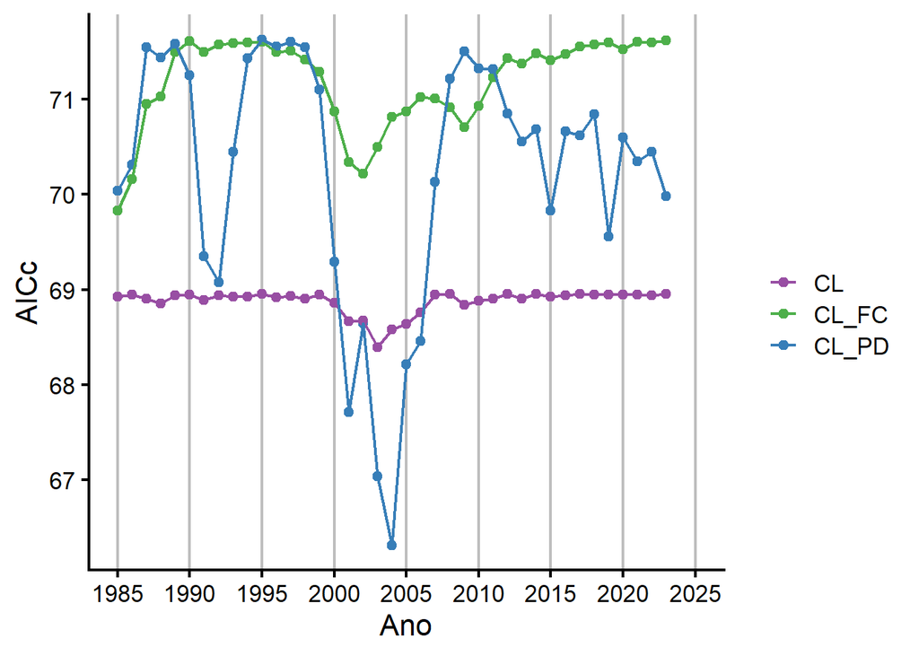

```r
##### Gráfico ----
library(ggplot2)
cols <- c("CL_PD" = "#377eb8", "CL_FC" = "#4daf4a", "CL" = "#984ea3")
TODOS <- ggplot(modelos_AIC, aes(x = as.numeric(ano), y = AICc))+
  theme_classic(base_size = 16)+
  geom_vline(xintercept = c(1985, 1990, 1995, 2000, 2005, 2010, 2015, 2020, 2025), color = "gray")+
  geom_point(aes(colour = factor(var)), size = 2)+
  geom_line(aes(x = as.numeric(ano), y = AICc, group = var, colour = factor(var)))+
  scale_x_continuous(breaks = c(1985, 1990, 1995, 2000, 2005, 2010, 2015, 2020, 2025))+
  scale_colour_manual(values = cols, name = "")+
  labs(x = "Ano", y = "AICc")
TODOS
```

Como esperado, de froma geral a estrura passada dos dados está melhor relacionada com a densidade atual de Callicebus barbarabrownae do que a estrutura atual.

Vou agora analisar o ajuste do modelo como menor valor de AIC. Que incluiu a densidade e a agregação dos fragmentos em 2004.

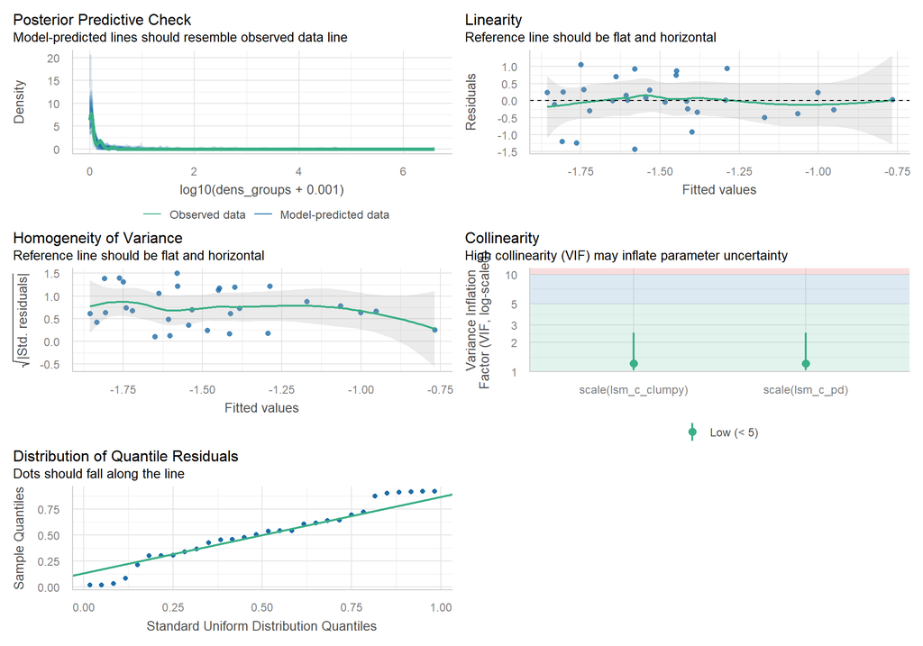

```r
library(performance)
res <- simulateResiduals(a2004_CL_PD, n=1000)
check_model(res)
```

O modelo ainda tem que ser melhor ajustado. Aqui vou fazer um exercício e mudar de distribuição gaussiana (normal) para a gamma, dessa vez sem transformar minha variavel resposta (sem logaritmizar).

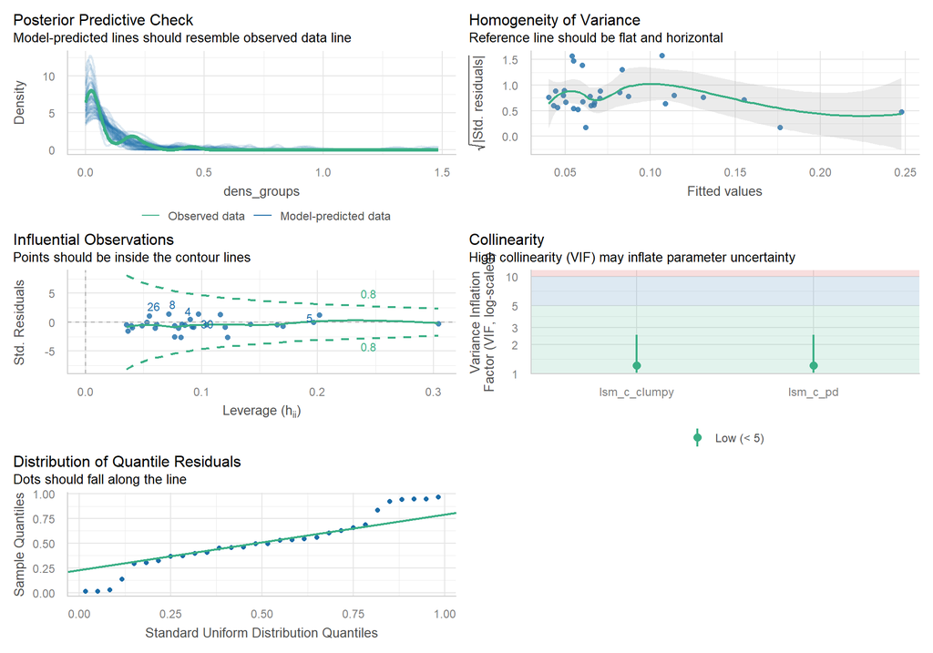

```r
a2004_CL_PD <- glm(dens_groups+0.0001 ~ lsm_c_clumpy + lsm_c_pd, family = Gamma(link = "log"),data = a2004)
res <- simulateResiduals(a2004_CL_PD, n=1000)
check_model(res)
```

Não parece ter melhorado, o modelo parece continuar superestimando quando os valores de densidade são mais baixos e subestimando quando os valores são mais altos.

## 3.3 Analisando os resultados

O modelo não parece estar bem ajustado e talvez seguir para um GLMM seja uma boa opção nesse caso. De qualquer forma, irei interpretar os resultados do melhor modelo que explicou a densidade atual de *Callicebus barbarabrownae*, que incluiu clumpy (métrica de agregação) e densidade dos fragmentos em 2004.

```r
summary(a2004_CL_PD)
```

```
##
## Call:
## glm(formula = dens_groups + 1e-04 ~ lsm_c_clumpy + lsm_c_pd,
##     family = Gamma(link = "log"), data = a2004)
##
## Coefficients:
##              Estimate Std. Error t value Pr(>|t|)
## (Intercept)    2.8991     3.4424   0.842    0.407
## lsm_c_clumpy  -5.9056     3.9933  -1.479    0.151
## lsm_c_pd      -0.3873     0.2496  -1.552    0.132
##
## (Dispersion parameter for Gamma family taken to be 1.781274)
##
##     Null deviance: 68.383  on 29  degrees of freedom
## Residual deviance: 63.223  on 27  degrees of freedom
## AIC: -95.657
##
## Number of Fisher Scoring iterations: 12
```

Nenhuma das variáveis testadas parece contribuir significativamente com a variação da densidade de grupos de *Callicebus barbarabrownae*, mas o que podemos observar é que há uma tendência de que em paisagens com menor densidade de fragmento e menor agregação de fragmentos, haja uma maior densidade de grupos dessa espécie de primata.

# 4 GLM para dados categóricos

## 4.1 Introdução

Modelos lineares generalizados também podem ser aplicados a dados categóricos, isto é, variáveis cuja resposta assume categorias distintas (nomes), como sexo (fêmea ou macho), espécie, estágio de vida, etc. De forma semelhante aos dados binários, busca-se identificar como diferentes fatores explicam a probabilidade de ocorrência de uma ou mais categorias da variável resposta.

Nesta seção, utilizarei o conjunto de dados ´palmerpenguins_extended.rds´. O objetivo é avaliar como a métrica de saúde dos pinguins, classificada em “acima do peso”, “peso normal” e “abaixo do peso”, se relaciona com variáveis explicativas como estágio de vida, espécie e sexo.

```r
dados <- readRDS("D:/doutorado/relatorio_disciplina_marie/relatorio_disciplina_marie/categoricos/palmerpenguins_extended.rds")
str(dados)
```

```
## 'data.frame':    3430 obs. of  11 variables:
##  $ species          : chr  "Adelie" "Adelie" "Adelie" "Adelie" ...
##  $ island           : chr  "Biscoe" "Biscoe" "Biscoe" "Biscoe" ...
##  $ bill_length_mm   : num  53.4 49.3 55.7 38 60.7 35.7 61 66.1 61.4 54.9 ...
##  $ bill_depth_mm    : num  17.8 18.1 16.6 15.6 17.9 16.8 20.8 20.8 19.9 22.3 ...
##  $ flipper_length_mm: num  219 245 226 221 177 194 211 246 270 230 ...
##  $ body_mass_g      : num  5687 6811 5388 6262 4811 ...
##  $ sex              : chr  "female" "female" "female" "female" ...
##  $ diet             : chr  "fish" "fish" "fish" "fish" ...
##  $ life_stage       : chr  "adult" "adult" "adult" "adult" ...
##  $ health_metrics   : chr  "overweight" "overweight" "overweight" "overweight" ...
##  $ year             : int  2021 2021 2021 2021 2021 2021 2021 2021 2021 2021 ...
```

Primeiro, devemos transformar as varíaveis de “character” para “factor”.

```r
#Transformando as variáveis
cols <- c("species", "island", "sex", "diet", "life_stage", "health_metrics")
dados[, cols] <- lapply(dados[, cols], factor)
str(dados)
```

```
## 'data.frame':    3430 obs. of  11 variables:
##  $ species          : Factor w/ 3 levels "Adelie","Chinstrap",..: 1 1 1 1 1 1 1 1 1 1 ...
##  $ island           : Factor w/ 3 levels "Biscoe","Dream",..: 1 1 1 1 1 1 1 1 1 1 ...
##  $ bill_length_mm   : num  53.4 49.3 55.7 38 60.7 35.7 61 66.1 61.4 54.9 ...
##  $ bill_depth_mm    : num  17.8 18.1 16.6 15.6 17.9 16.8 20.8 20.8 19.9 22.3 ...
##  $ flipper_length_mm: num  219 245 226 221 177 194 211 246 270 230 ...
##  $ body_mass_g      : num  5687 6811 5388 6262 4811 ...
##  $ sex              : Factor w/ 2 levels "female","male": 1 1 1 1 1 1 1 2 2 2 ...
##  $ diet             : Factor w/ 4 levels "fish","krill",..: 1 1 1 1 1 1 1 1 1 1 ...
##  $ life_stage       : Factor w/ 3 levels "adult","chick",..: 1 1 1 1 3 3 1 1 1 1 ...
##  $ health_metrics   : Factor w/ 3 levels "healthy","overweight",..: 2 2 2 2 2 2 2 2 2 2 ...
##  $ year             : int  2021 2021 2021 2021 2021 2021 2021 2021 2021 2021 ...
```

## 4.2 Análise exploratória

Quantos pinguins estão acima ou abaixo do peso?

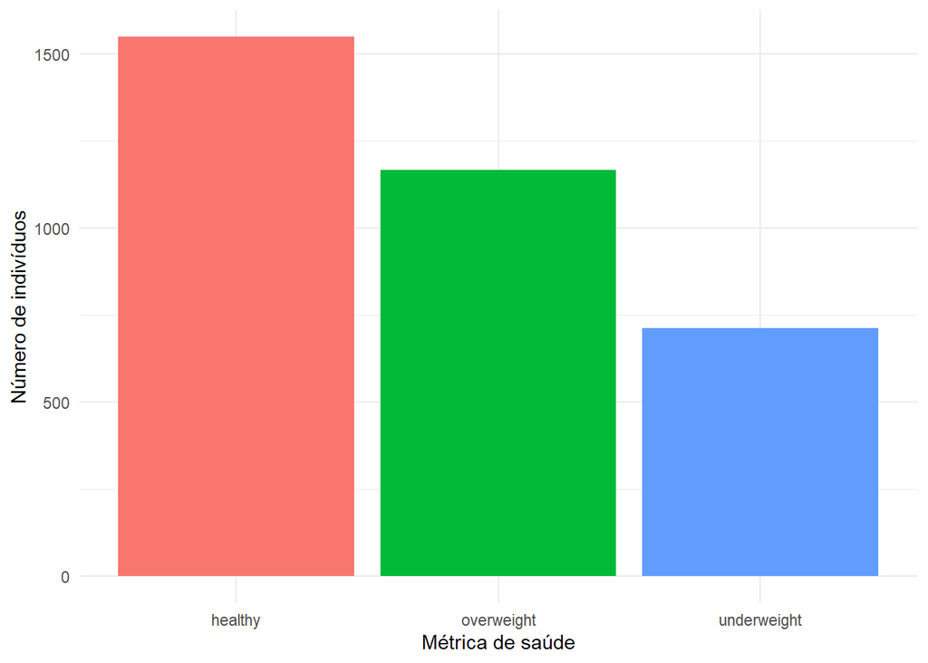

```r
ggplot(dados, aes(x = health_metrics, fill = health_metrics)) +
  geom_bar() +
  labs(x = "Métrica de saúde", y = "Número de indivíduos") +
  theme_minimal() +
  theme(legend.position = "none")
```

A maioria dos pinguins parece estar classificada como em sobrepeso ou abaixo do peso. Como será que isso é dentro de cada espécie?

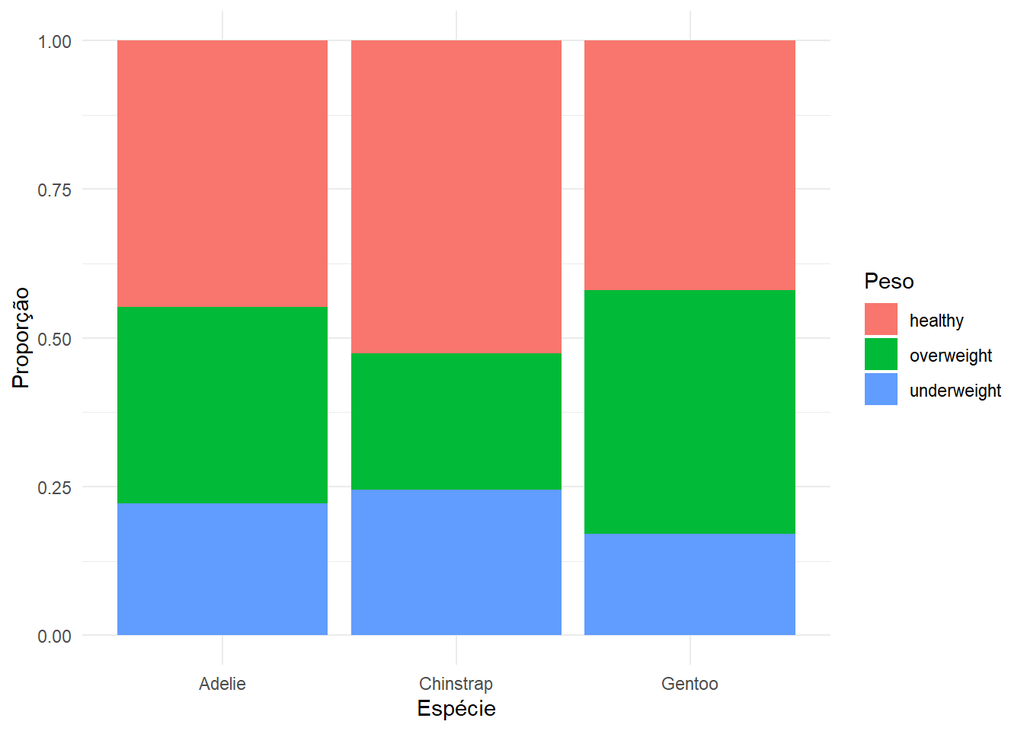

```r
ggplot(dados, aes(x = species, fill = health_metrics)) +
  geom_bar(position = "fill") +
  labs(x = "Espécie", y = "Proporção", fill = "Peso") +
  theme_minimal()
```

Gentoo é a espécie com maior proporção de pinguins com sobrepeso, enquanto Chinstrap parece ter ligeiramente uma maior proporção de pinguins abaixo do peso. Será que tem diferença para os sexos?

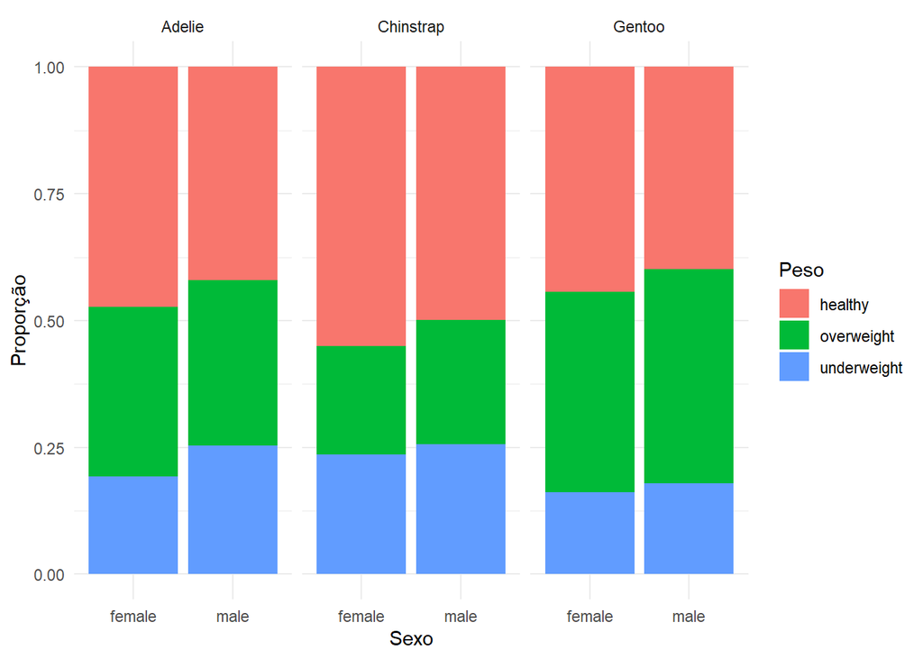

```r
ggplot(dados, aes(x = sex, fill = health_metrics)) +
  geom_bar(position = "fill") +
  facet_wrap(~ species) +
  labs(x = "Sexo", y = "Proporção",fill = "Peso") +
  theme_minimal()
```

Dentro de cada espécie, a categoria de saúde (saudável, sobrepeso, abaixo do peso) não parece ser influenciada pelo sexo.

## 4.3 Gerando modelos

Antes de ajustar os modelos, devemos definir o nível de referência.

```r
levels(dados$health_metrics)
```

```
## [1] "healthy"     "overweight"  "underweight"
```

Nesse caso o nível saudável é o primeiro e ele pode ser um bom nível de referência.

```r
library(VGAM)
# Modelos
modelo_1 <- vglm(health_metrics ~ species, family = multinomial(refLevel = 1), data = dados)
modelo_2 <- vglm(health_metrics ~ species + sex, family = multinomial(refLevel = 1), data = dados)
modelo_3 <- vglm(health_metrics ~ species + sex + diet, family = multinomial(refLevel = 1), data = dados)
modelo_4 <- vglm(health_metrics ~ species + sex + diet + island, family = multinomial(refLevel = 1), data = dados) #pode depender da ilha em que esão os penguins também

#AIC
aic_m1 <- AIC(modelo_1)
aic_m2 <- AIC(modelo_2)
aic_m3 <- AIC(modelo_3)
aic_m4 <- AIC(modelo_4)

aic_tabela <- data.frame(Modelo = c("modelo_1", "modelo_2", "modelo_3", "modelo_4"),
                         AIC = c(aic_m1, aic_m2, aic_m3, aic_m4))
aic_tabela <- aic_tabela[order(aic_tabela$AIC), ]
print(aic_tabela)
```

```
##     Modelo      AIC
## 3 modelo_3 5375.117
## 4 modelo_4 5378.235
## 2 modelo_2 7156.530
## 1 modelo_1 7163.254
```

Parece que os modelos 3 e 4 explicam bem melhor a variação na métrica de saúde dos penguins.

## 4.4 Analisando resultados

Apesar de o modelo 3 e o modelo 4 terem valores bem semelhantes de AIC, o modelo que inclui a ilha parece não agregar tanto. Por isso, vou analisar os resultados do primeiro modelo unicamente. O modelo incluiu a espécie, o sexo e a dieta como variáveis explanatórias.

```r
summary(modelo_3)
```

```
##
## Call:
## vglm(formula = health_metrics ~ species + sex + diet, family = multinomial(refLevel = 1),
##     data = dados)
##
## Coefficients:
##                    Estimate Std. Error z value Pr(>|z|)
## (Intercept):1       1.71511    0.11911  14.399  < 2e-16 ***
## (Intercept):2      -3.42038    0.46102  -7.419 1.18e-13 ***
## speciesChinstrap:1 -0.30018    0.14505  -2.069 0.038506 *
## speciesChinstrap:2 -0.13811    0.12136  -1.138 0.255124
## speciesGentoo:1    -0.20762    0.11213  -1.852 0.064072 .
## speciesGentoo:2    -0.08599    0.10840  -0.793 0.427658
## sexmale:1           0.33332    0.10107   3.298 0.000974 ***
## sexmale:2           0.27331    0.09366   2.918 0.003522 **
## dietkrill:1        -3.57892    0.13660 -26.200  < 2e-16 ***
## dietkrill:2         3.01304    0.45905   6.564 5.25e-11 ***
## dietparental:1     -2.97531    0.12980 -22.923  < 2e-16 ***
## dietparental:2      2.06452    0.46443   4.445 8.78e-06 ***
## dietsquid:1        -2.15118    0.17843 -12.056  < 2e-16 ***
## dietsquid:2         1.13964    0.54764   2.081 0.037434 *
## ---
## Signif. codes:  0 '***' 0.001 '**' 0.01 '*' 0.05 '.' 0.1 ' ' 1
##
## Names of linear predictors: log(mu[,2]/mu[,1]), log(mu[,3]/mu[,1])
##
## Residual deviance: 5347.117 on 6846 degrees of freedom
##
## Log-likelihood: -2673.558 on 6846 degrees of freedom
##
## Number of Fisher scoring iterations: 7
##
## Warning: Hauck-Donner effect detected in the following estimate(s):
## '(Intercept):2'
##
##
## Reference group is level  1  of the response
```

A variável resposta (health_metrics) tem três categorias, que estão niveladas da seguinte forma: - 1: “healthy” (saudável) — nível de referência, - 2: “overweight” (acima do peso). - 3: “underweight” (abaixo do peso),

O modelo estima dois conjuntos de coeficientes,que quando terminam em:

- “:1”, é log-odds de estar em “overweight” vs “healthy”;
- “:2”, é log-odds de estar em “underweight” vs “healthy”.

O log-odds, é o logit (logaritmo natural da razão de chances de um evento).

Dessa forma, podemos converter e entender as razões de chance da seguinte forma:

```r
exp(coef(modelo_3))
```

```
##      (Intercept):1      (Intercept):2 speciesChinstrap:1 speciesChinstrap:2
##         5.55729534         0.03270014         0.74068716         0.87100475
##    speciesGentoo:1    speciesGentoo:2          sexmale:1          sexmale:2
##         0.81251330         0.91760743         1.39559349         1.31430622
##        dietkrill:1        dietkrill:2     dietparental:1     dietparental:2
##         0.02790591        20.34920978         0.05103152         7.88153714
##        dietsquid:1        dietsquid:2
##         0.11634645         3.12563032
```